# Final project: Data Science Pipeline Tutorial

### By: Elliot Huang, Naman Molri, Samuel Scheffler & Shahnur Syed

```python
import pandas as pd
import matplotlib.pyplot as plt
import numpy as np
import seaborn as sns
from sklearn import preprocessing
from sklearn.linear_model import LinearRegression
import statsmodels.api as sm
```

## About the project:

The goal of this project is to create a tutorial for Data Science by performing essential DS pipeline steps on real data. We are using Affordable Housing data throughout the USA to show how the Data Science Pipeline can be used to attain useful information and make reasonable comparisions and conclusions. For example, we can find out what racial or age demographic inhibits these affordable apartments and use our historical knowledge to make reasonable assumption about these housing initiatives. This is also a tutorial of how evidence found in the data pipeline can be used conclusively, and our plan is to show that by cleaning, analysing and medling our Affordable housing data in this project.

## Phase 1&2: Data Collection and Management

### 1) Data Collection:

The data that is being used for this project is taken from the website of U.S. Department of Housing and Urban Development's (HUD's). This department is responsible for collecting and managing data on Housing and Urban planning. The data being used for the project is the Affordable housing data from 2018, reported by the department. The data collected conatins all the required categories our group was looking for the project. It is reported classified by Race, Age, Income, Disability of occupants and many more relevant categories that we plan to use throughout the project to analyse and hypothesize conclusions based on the aforementioned classifications.

Links to the datasets:

Multiple datasets: (including categories occupants by race, age, disability etc)

https://www.huduser.gov/portal/datasets/lihtc/tenant.html

State 2018 dataset: https://www.huduser.gov/portal/datasets/assthsg.html#2009-2020_data

### Data Management:

Most of the data that was obtained from the Housing and Urban Development department's website was in excel format with varied column names and many irrelevant categories. For all the tables below we cleaned the data up to only include relevant columns with reasonable names. The biggest classifier for us, in exploratory analysis, is State, so we used pandas functionalities to match that columns across all our datasets. The data tables we focused on are reporting on the age, race, disability status and income of teh occupants. They also report on the units of affordable housing in each state and what percentage of units request federal or other monetary assistance.

The table below is the summary of all the HUD programs for affordable housing in each state. We have cleaned the table to only include relevant information regrading the occupants and housing units. Also used python functionalities like str.slice and value-match from pandas to filter out the unnecessary values.

```python
pd.set_option('display.max_columns', None)
state_2018 = pd.read_excel("STATE_2018.xlsx")
state_2018 = state_2018.drop(['sub_program', 'entities', 'sumlevel', 'gsl', 'name', 'fedhse',
                              'cbsa', 'place', 'latitude', 'longitude', 'State',
                              'pha_total_units', 'months_since_report','pct_reported',
                              'pct_wage_major','pct_other_major','pct_lt50_median',
                              'pct_2adults','pct_1adult','pct_female_head',
                              'pct_female_head_child', 'pct_disabled_lt62','pct_disabled_ge62',
                              'pct_minority', 'pct_black_hsp','pct_wht_hsp','pct_oth_hsp',
                              'pct_multi','pct_median','months_waiting','months_from_movein',
                              'pct_bed1','pct_bed2','pct_bed3','pct_overhoused',
                              'tpoverty','tminority','tpct_ownsfd', 'pct_utility_allow',
                              'ave_util_allow', 'program', 'code', 'Quarter',
                              'ha_size'], axis=1)
state_2018 = state_2018[state_2018.program_label == 'Summary of All HUD Programs']
state_2018['States'] = state_2018['States'].str.slice(2)
state_2018.index = state_2018["States"].values
state_2018 = state_2018[state_2018.States != 'XX Missing']
state_2018 = state_2018.drop(columns=['States', 'program_label'])
state_2018 = state_2018.rename(columns={'total_units':'Total Units', 'pct_occupied':'Units Occupied (%)',
                           'number_reported':'Units Reported', 'people_total': 'Number of total Occupants',
                            'pct_movein':'% moved in less than 1 year', 'people_per_unit':'Occupancy/unit',
                            'rent_per_month':'Rent', 'spending_per_month':'Monthly Budget', 'hh_income':
                            'Household Income', 'person_income': 'Average Personal Income', 'pct_lt5k':
                            'Household Income %- (\$1-$5k)',
                            'pct_5k_lt10k': 'Household Income %- (\$5k-$10k)',
                            'pct_10k_lt15k': 'Household Income %- (\$10k-$15k)', 'pct_15k_lt20k':
                            'Household Income %- (\$15k-$20k)',
                            'pct_ge20k': 'Household Income %- (over \$20k)',
                            'pct_welfare_major':'% dependant on welfare', 'pct_lt30_median':
                            '% below 30% median wage', 'pct_disabled_all':'% of disabled occupants',
                            'pct_lt24_head': 'Age of Household Head % - <24', 'pct_age25_50':
                            'Age of Household Head % -(25-50)',
                            'pct_age51_61': 'Age of Household Head % -(51-61)',
                            'pct_age62plus': 'Age of Household Head % -(62 plus)',
                            'pct_age85plus':'Age of Household Head % -(85 plus)',
                            'pct_black_nonhsp': 'Occupants Race: Black',
                            'pct_native_american_nonhsp': 'Occupants Race: Native American',
                            'pct_asian_pacific_nonhsp': 'Occupants Race: Asian',
                            'pct_white_nothsp':'Occupants Race: White',
                            'pct_hispanic': 'Occupants Race: Hispanic',})
state_2018
```

|  | Total Units | Units Occupied (%) | Units Reported | % moved in less than 1 year | Occupancy/unit | Number of total Occupants | Rent | Monthly Budget | Household Income | Average Personal Income | Household Income %- (\$1-$5k) | Household Income %- (\$5k-$10k) | Household Income %- (\$10k-$15k) | Household Income %- (\$15k-$20k) | Household Income %- (over \$20k) | % dependant on welfare | % below 30% median wage | % of disabled occupants | Age of Household Head % - <24 | Age of Household Head % -(25-50) | Age of Household Head % -(51-61) | Age of Household Head % -(62 plus) | Age of Household Head % -(85 plus) | Occupants Race: Black | Occupants Race: Native American | Occupants Race: Asian | Occupants Race: White | Occupants Race: Hispanic |
| --- | --- | --- | --- | --- | --- | --- | --- | --- | --- | --- | --- | --- | --- | --- | --- | --- | --- | --- | --- | --- | --- | --- | --- | --- | --- | --- | --- | --- |
| Alabama | 91524 | 91 | 83571 | 16 | 2.2 | 181896 | 273 | 547 | 12063 | 5542 | 15 | 34 | 23 | 14 | 14 | 2 | 69 | 17 | 7 | 51 | 17 | 25 | 2 | 73 | 0 | 0 | 25 | 1 |
| Alaska | 7783 | 101 | 7740 | 16 | 2.1 | 16618 | 529 | 649 | 20491 | 9544 | 7 | 6 | 23 | 28 | 35 | 6 | 72 | 22 | 3 | 44 | 22 | 31 | 2 | 14 | 22 | 12 | 45 | 7 |
| Arizona | 41000 | 92 | 39000 | 11 | 2.3 | 89373 | 313 | 629 | 12817 | 5593 | 12 | 34 | 23 | 13 | 18 | 1 | 71 | 19 | 2 | 41 | 20 | 37 | 3 | 22 | 3 | 2 | 35 | 36 |
| Arkansas | 50521 | 90 | 45192 | 22 | 2.0 | 88799 | 272 | 448 | 11717 | 5963 | 12 | 37 | 26 | 14 | 11 | 1 | 64 | 24 | 8 | 43 | 20 | 29 | 2 | 51 | 0 | 0 | 45 | 2 |
| California | 491113 | 90 | 451733 | 7 | 2.1 | 945541 | 444 | 1040 | 17182 | 8209 | 5 | 10 | 43 | 16 | 26 | 8 | 78 | 24 | 1 | 32 | 20 | 46 | 7 | 28 | 1 | 16 | 27 | 28 |
| Colorado | 61820 | 91 | 56039 | 12 | 2.0 | 112509 | 335 | 737 | 13691 | 6819 | 9 | 33 | 24 | 15 | 19 | 5 | 81 | 25 | 3 | 39 | 21 | 37 | 3 | 19 | 1 | 2 | 45 | 29 |
| Connecticut | 82830 | 92 | 76242 | 8 | 2.0 | 152497 | 390 | 1222 | 16090 | 8044 | 7 | 28 | 20 | 15 | 28 | 3 | 81 | 21 | 2 | 40 | 20 | 38 | 5 | 30 | 0 | 1 | 28 | 39 |
| Delaware | 13030 | 91 | 11952 | 10 | 2.1 | 24849 | 350 | 718 | 14702 | 7072 | 9 | 26 | 24 | 17 | 24 | 3 | 75 | 19 | 6 | 42 | 19 | 34 | 3 | 68 | 0 | 1 | 22 | 7 |
| District of Columbia | 34477 | 83 | 28185 | 5 | 2.1 | 58427 | 364 | 1215 | 15257 | 7360 | 9 | 34 | 18 | 11 | 28 | 8 | 85 | 19 | 2 | 40 | 24 | 34 | 3 | 90 | 0 | 2 | 1 | 4 |
| Florida | 195822 | 92 | 184375 | 9 | 2.2 | 407463 | 343 | 744 | 13618 | 6162 | 10 | 36 | 21 | 13 | 19 | 1 | 73 | 21 | 3 | 41 | 17 | 39 | 4 | 52 | 0 | 1 | 17 | 29 |
| Georgia | 135993 | 89 | 124392 | 13 | 2.3 | 283901 | 298 | 641 | 12830 | 5622 | 12 | 32 | 23 | 14 | 18 | 1 | 70 | 16 | 5 | 49 | 17 | 29 | 2 | 83 | 0 | 1 | 13 | 2 |
| Hawaii | 22801 | 83 | 19133 | 11 | 2.5 | 48315 | 446 | 996 | 18336 | 7261 | 6 | 28 | 19 | 13 | 33 | 4 | 80 | 18 | 2 | 38 | 21 | 39 | 4 | 3 | 1 | 64 | 19 | 12 |
| Idaho | 12533 | 90 | 11435 | 17 | 2.0 | 22327 | 324 | 501 | 13273 | 6798 | 7 | 35 | 27 | 16 | 16 | 0 | 68 | 31 | 4 | 41 | 21 | 35 | 3 | 4 | 2 | 1 | 82 | 10 |
| Illinois | 226660 | 91 | 208419 | 11 | 2.0 | 412356 | 321 | 822 | 13301 | 6723 | 11 | 33 | 21 | 14 | 21 | 2 | 77 | 20 | 4 | 41 | 19 | 36 | 4 | 63 | 0 | 2 | 27 | 6 |
| Indiana | 92744 | 89 | 80995 | 17 | 1.9 | 157611 | 283 | 528 | 11720 | 6023 | 14 | 32 | 25 | 15 | 14 | 1 | 74 | 23 | 7 | 43 | 20 | 30 | 3 | 44 | 0 | 1 | 51 | 3 |
| Iowa | 40506 | 81 | 36092 | 20 | 1.8 | 64587 | 306 | 458 | 12780 | 7142 | 8 | 32 | 28 | 17 | 15 | 2 | 75 | 27 | 5 | 38 | 21 | 36 | 5 | 21 | 1 | 1 | 73 | 3 |
| Kansas | 35074 | 88 | 30924 | 20 | 1.7 | 53689 | 293 | 468 | 13170 | 7585 | 9 | 30 | 28 | 16 | 17 | 1 | 70 | 26 | 6 | 35 | 21 | 38 | 4 | 29 | 1 | 1 | 61 | 6 |
| Kentucky | 85015 | 89 | 75865 | 18 | 2.0 | 151318 | 270 | 480 | 11636 | 5834 | 16 | 36 | 23 | 13 | 13 | 2 | 73 | 24 | 7 | 43 | 21 | 29 | 2 | 33 | 0 | 0 | 64 | 2 |
| Louisiana | 93912 | 88 | 83266 | 13 | 2.3 | 187825 | 294 | 615 | 12345 | 5473 | 13 | 38 | 21 | 14 | 15 | 1 | 71 | 20 | 5 | 50 | 18 | 27 | 2 | 84 | 0 | 0 | 13 | 2 |
| Maine | 26513 | 92 | 24697 | 12 | 1.8 | 44748 | 347 | 737 | 14605 | 8061 | 4 | 31 | 28 | 17 | 20 | 2 | 68 | 32 | 2 | 36 | 21 | 41 | 5 | 7 | 1 | 1 | 87 | 1 |
| Maryland | 100087 | 89 | 90199 | 9 | 2.1 | 186566 | 382 | 968 | 15906 | 7690 | 8 | 31 | 21 | 14 | 27 | 4 | 80 | 24 | 2 | 43 | 21 | 34 | 4 | 72 | 0 | 3 | 21 | 3 |
| Massachusetts | 195860 | 94 | 182776 | 7 | 1.9 | 348284 | 425 | 1039 | 17941 | 9415 | 4 | 15 | 33 | 17 | 31 | 4 | 75 | 27 | 1 | 36 | 21 | 41 | 5 | 20 | 0 | 5 | 42 | 31 |
| Michigan | 145631 | 92 | 134537 | 13 | 1.9 | 252916 | 299 | 556 | 12595 | 6700 | 12 | 34 | 24 | 15 | 16 | 1 | 72 | 24 | 5 | 40 | 19 | 36 | 4 | 51 | 1 | 1 | 42 | 3 |
| Minnesota | 89982 | 92 | 84642 | 13 | 2.1 | 173643 | 357 | 571 | 15402 | 7508 | 8 | 24 | 28 | 16 | 25 | 6 | 76 | 23 | 4 | 40 | 20 | 36 | 4 | 38 | 2 | 4 | 52 | 3 |
| Mississippi | 55739 | 94 | 52540 | 15 | 2.4 | 125291 | 266 | 546 | 11451 | 4802 | 18 | 34 | 22 | 13 | 13 | 1 | 66 | 16 | 5 | 55 | 17 | 23 | 1 | 84 | 0 | 0 | 14 | 1 |
| Missouri | 91753 | 91 | 82712 | 16 | 2.0 | 163414 | 288 | 517 | 12372 | 6262 | 10 | 34 | 26 | 15 | 16 | 1 | 74 | 22 | 5 | 43 | 20 | 32 | 3 | 50 | 1 | 1 | 45 | 2 |
| Montana | 13843 | 86 | 12095 | 17 | 1.8 | 22055 | 293 | 501 | 12507 | 6859 | 9 | 33 | 27 | 15 | 15 | 2 | 74 | 29 | 5 | 39 | 21 | 34 | 4 | 2 | 12 | 1 | 81 | 4 |
| Nebraska | 27855 | 89 | 24859 | 17 | 2.0 | 48561 | 323 | 433 | 14241 | 7290 | 7 | 27 | 27 | 17 | 22 | 3 | 72 | 22 | 5 | 41 | 20 | 34 | 4 | 28 | 2 | 1 | 61 | 6 |
| Nevada | 23440 | 95 | 22164 | 7 | 2.3 | 50609 | 349 | 713 | 13189 | 5776 | 13 | 30 | 24 | 14 | 19 | 2 | 74 | 23 | 2 | 45 | 21 | 31 | 2 | 48 | 1 | 3 | 33 | 14 |
| New Hampshire | 21312 | 95 | 20717 | 11 | 1.7 | 34968 | 393 | 706 | 16806 | 9957 | 2 | 23 | 27 | 21 | 28 | 2 | 73 | 34 | 2 | 31 | 21 | 46 | 6 | 4 | 1 | 1 | 86 | 8 |
| New Jersey | 165436 | 94 | 154259 | 8 | 1.9 | 300803 | 401 | 904 | 16796 | 8614 | 6 | 29 | 21 | 15 | 29 | 2 | 77 | 20 | 1 | 34 | 19 | 45 | 6 | 42 | 0 | 3 | 25 | 28 |
| New Mexico | 25819 | 85 | 22064 | 15 | 2.1 | 46262 | 282 | 523 | 11759 | 5609 | 12 | 39 | 24 | 13 | 12 | 4 | 73 | 25 | 5 | 43 | 21 | 32 | 2 | 6 | 7 | 1 | 27 | 59 |
| New York | 592467 | 92 | 544084 | 6 | 2.1 | 1134562 | 454 | 936 | 19046 | 9134 | 5 | 18 | 32 | 14 | 32 | 6 | 75 | 24 | 2 | 34 | 23 | 41 | 6 | 34 | 0 | 4 | 38 | 24 |
| North Carolina | 123396 | 92 | 115669 | 13 | 2.2 | 249340 | 282 | 540 | 11830 | 5488 | 14 | 34 | 25 | 14 | 14 | 1 | 72 | 20 | 5 | 47 | 19 | 29 | 2 | 70 | 1 | 1 | 24 | 3 |
| North Dakota | 13362 | 78 | 10407 | 22 | 1.8 | 18575 | 305 | 470 | 13477 | 7551 | 10 | 28 | 28 | 16 | 18 | 1 | 82 | 28 | 6 | 41 | 20 | 32 | 4 | 11 | 9 | 2 | 74 | 3 |
| Ohio | 224569 | 94 | 212970 | 15 | 2.0 | 422063 | 268 | 573 | 11093 | 5597 | 15 | 35 | 22 | 13 | 14 | 1 | 79 | 23 | 7 | 44 | 20 | 29 | 2 | 52 | 0 | 0 | 42 | 4 |
| Oklahoma | 53072 | 92 | 48849 | 21 | 2.0 | 97386 | 262 | 496 | 10916 | 5475 | 18 | 34 | 24 | 13 | 11 | 2 | 76 | 24 | 8 | 44 | 20 | 28 | 2 | 39 | 7 | 1 | 48 | 5 |
| Oregon | 52887 | 93 | 50219 | 11 | 1.9 | 97522 | 354 | 637 | 13379 | 6889 | 5 | 37 | 26 | 14 | 18 | 5 | 72 | 29 | 2 | 39 | 23 | 36 | 3 | 11 | 3 | 4 | 73 | 9 |
| Pennsylvania | 220602 | 90 | 200700 | 11 | 1.9 | 381840 | 327 | 666 | 13977 | 7347 | 8 | 33 | 24 | 16 | 20 | 3 | 73 | 26 | 4 | 37 | 19 | 40 | 5 | 39 | 0 | 1 | 47 | 11 |
| Rhode Island | 37973 | 93 | 35582 | 9 | 1.7 | 60555 | 354 | 764 | 15179 | 8919 | 5 | 32 | 23 | 16 | 24 | 1 | 71 | 28 | 2 | 30 | 21 | 47 | 6 | 12 | 1 | 1 | 55 | 29 |
| South Carolina | 62570 | 94 | 58950 | 13 | 2.2 | 130665 | 277 | 574 | 11950 | 5391 | 18 | 31 | 23 | 13 | 16 | 1 | 70 | 16 | 6 | 51 | 18 | 26 | 2 | 80 | 0 | 0 | 17 | 1 |
| South Dakota | 13814 | 85 | 11736 | 18 | 1.8 | 21591 | 290 | 463 | 12753 | 6932 | 9 | 29 | 28 | 17 | 17 | 1 | 73 | 27 | 6 | 41 | 20 | 33 | 5 | 5 | 20 | 1 | 70 | 3 |
| Tennessee | 104709 | 92 | 97829 | 16 | 2.0 | 199757 | 273 | 536 | 11635 | 5698 | 17 | 33 | 23 | 13 | 14 | 2 | 71 | 20 | 7 | 44 | 19 | 30 | 2 | 53 | 0 | 0 | 44 | 2 |
| Texas | 277542 | 90 | 252651 | 14 | 2.3 | 588829 | 317 | 626 | 13005 | 5580 | 12 | 35 | 22 | 13 | 18 | 1 | 74 | 20 | 5 | 48 | 18 | 29 | 2 | 46 | 0 | 2 | 17 | 34 |
| Utah | 19006 | 93 | 17928 | 16 | 2.0 | 35991 | 330 | 572 | 13252 | 6601 | 7 | 34 | 26 | 15 | 18 | 2 | 79 | 28 | 3 | 42 | 21 | 34 | 2 | 8 | 2 | 4 | 71 | 15 |
| Vermont | 12866 | 89 | 11865 | 11 | 1.8 | 20911 | 369 | 711 | 15579 | 8840 | 3 | 29 | 28 | 17 | 23 | 5 | 71 | 33 | 3 | 36 | 21 | 41 | 5 | 4 | 1 | 2 | 90 | 1 |
| Virginia | 103501 | 92 | 95492 | 11 | 2.2 | 207852 | 325 | 709 | 13668 | 6279 | 13 | 31 | 22 | 13 | 21 | 2 | 77 | 19 | 5 | 46 | 19 | 30 | 3 | 66 | 0 | 3 | 25 | 4 |
| Washington | 89999 | 92 | 86465 | 10 | 2.0 | 173012 | 359 | 747 | 14788 | 7391 | 7 | 37 | 24 | 13 | 21 | 5 | 80 | 29 | 2 | 38 | 22 | 38 | 4 | 21 | 2 | 10 | 59 | 7 |
| West Virginia | 34273 | 90 | 30967 | 19 | 1.8 | 56096 | 266 | 494 | 11175 | 6169 | 13 | 39 | 24 | 14 | 11 | 2 | 69 | 26 | 7 | 40 | 22 | 31 | 2 | 15 | 0 | 0 | 82 | 1 |
| Wisconsin | 77168 | 90 | 69151 | 14 | 1.7 | 119284 | 330 | 471 | 14080 | 8163 | 6 | 13 | 45 | 18 | 19 | 1 | 72 | 29 | 4 | 35 | 21 | 40 | 5 | 30 | 1 | 2 | 60 | 5 |
| Wyoming | 5764 | 91 | 5285 | 19 | 1.7 | 8816 | 304 | 513 | 13145 | 7880 | 9 | 30 | 27 | 18 | 16 | 1 | 79 | 28 | 6 | 35 | 21 | 38 | 4 | 4 | 3 | 0 | 80 | 11 |
| Guam | 3380 | 91 | 3127 | 13 | 4.1 | 12916 | 292 | 973 | 12675 | 3069 | 33 | 13 | 14 | 17 | 24 | 5 | 68 | 4 | 4 | 66 | 17 | 14 | 1 | 0 | 0 | 98 | 1 | 0 |
| Northern Mariana Islands | 481 | 90 | 423 | 15 | 4.5 | 1910 | 209 | 844 | 9298 | 2059 | 41 | 17 | 12 | 17 | 12 | 0 | -1 | 4 | 5 | 69 | 15 | 10 | -1 | -1 | -1 | 99 | 1 | 0 |
| Puerto Rico | 107389 | 94 | 99853 | 14 | 2.3 | 225579 | 106 | 614 | 4666 | 2065 | 52 | 27 | 13 | 6 | 3 | 8 | 73 | 6 | 8 | 52 | 17 | 23 | 2 | 0 | 0 | 0 | 0 | 99 |
| U.S. Virgin Islands | 6512 | 78 | 4718 | 10 | 2.4 | 11131 | 278 | 980 | 12951 | 5489 | 35 | 18 | 13 | 9 | 25 | 8 | 64 | 6 | 5 | 48 | 19 | 27 | 3 | 80 | 0 | 0 | 1 | 18 |
| Missing | 93 | 96 | 516 | 10 | 2.2 | 1156 | 892 | 875 | 19152 | 8549 | 7 | 15 | 19 | 16 | 43 | 2 | -1 | 13 | 3 | 45 | 20 | 32 | 2 | 42 | -1 | 1 | 23 | 29 |

This table reports the occupants by their race in these affordable housing units across the states. The categories include Black (African American), White, Asian, Native American and the Other races. HUD also reports on units where race was not reported.

```python
race_of_occp_df = pd.read_excel("2018-LIHTC-Tenant-Tables.xlsx", sheet_name="Table 4")

##Dropping columns
race_of_occp_df = race_of_occp_df.drop(columns="Unnamed: 10")

##Renaming cols to match actual dataset
race_of_occp_df.iloc[0, 0] = race_of_occp_df.iloc[1, 0]
race_of_occp_df.iloc[0, 2:8] = race_of_occp_df.iloc[1, 2:8]
race_of_occp_df.iloc[0, 9] = race_of_occp_df.iloc[1, 9]
race_of_occp_df.columns = race_of_occp_df.iloc[0]

##Dropping rows that are irrelevant
race_of_occp_df = race_of_occp_df.drop(race_of_occp_df.index[57:81])
race_of_occp_df = race_of_occp_df.drop([0,1])
##Getting rid of footnote
race_of_occp_df = race_of_occp_df.replace(to_replace = "New York1", value = "New York")

##Renaming indices
race_of_occp_df.index = race_of_occp_df.State.values

##Removing extra whitespaces from column names
race_of_occp_df.columns = race_of_occp_df.columns.str.replace('\s{2,}',' ', regex=True)

race_of_occp_df
```

|  | State | Properties Reported (%) | White Alone (%) | Black or African American Alone (%) | Asian Alone (%) | American Indian and Alaska Native Alone (%) | Native Hawaiian and Other Pacific Islander Alone (%) | Other (including Multiple Race) (%) | Hispanic (Any Race) (%) | Race or Ethnicity Not Reported (%) |
| --- | --- | --- | --- | --- | --- | --- | --- | --- | --- | --- |
| Alabama | Alabama | 86.36364 | 34.45933 | 63.74529 | 0.30981 | 0.20529 | 0.10451 | 0.80624 | 0.35086 | 0.01866 |
| Alaska | Alaska | 100.00000 | 52.25753 | 6.68896 | 4.18060 | 18.22743 | 2.17391 | 0.25084 | 4.34783 | 11.87291 |
| Arizona | Arizona | 94.71154 | 35.68655 | 13.70379 | 1.21932 | 7.16837 | 0.29124 | 2.15129 | 33.10811 | 6.67133 |
| Arkansas | Arkansas | 98.32869 | 42.98514 | 43.62179 | 0.37727 | 0.25937 | 10.98797 | 0.56590 | 1.20255 | 0.00000 |
| California | California | 81.15494 | 24.97301 | 18.02942 | 0.00000 | 0.84126 | 0.00000 | 3.44880 | 38.61794 | 14.08958 |
| Colorado | Colorado | 84.25605 | 35.71180 | 11.20104 | 1.28039 | 0.70817 | 0.11065 | 3.39224 | 21.33350 | 26.26221 |
| Connecticut | Connecticut | 91.57895 | 30.98213 | 27.23370 | 0.01745 | 0.52352 | 0.00000 | 1.83582 | 29.51277 | 9.89460 |
| Delaware | Delaware | 98.42520 | 24.79282 | 65.19337 | 0.69061 | 0.63536 | 0.15193 | 0.95304 | 7.56906 | 0.01381 |
| District of Columbia | District of Columbia | 71.96262 | 2.46130 | 80.92712 | 0.34789 | 0.18264 | 0.07827 | 0.97408 | 6.07932 | 8.94938 |
| Florida | Florida | 92.34194 | 0.00000 | 0.00000 | 0.00000 | 0.00000 | 0.00000 | 0.00000 | 0.00000 | 100.00000 |
| Georgia | Georgia | 87.06522 | 19.02480 | 75.32427 | 1.16118 | 0.23605 | 0.10491 | 1.59275 | 2.54888 | 0.00715 |
| Guam | Guam | 100.00000 | 4.57143 | 1.90476 | 47.23810 | 0.57143 | 0.00000 | 44.00000 | 0.76190 | 0.95238 |
| Hawaii | Hawaii | 92.15686 | 43.50032 | 4.81928 | 0.00000 | 1.26823 | 0.00000 | 8.97273 | 11.31896 | 30.12048 |
| Idaho | Idaho | 99.16667 | 80.15055 | 2.70990 | 0.00000 | 1.54024 | 0.00000 | 1.27389 | 9.54256 | 4.78286 |
| Illinois | Illinois | 71.12069 | 41.97026 | 49.41281 | 0.56901 | 0.18361 | 0.13634 | 1.42888 | 6.17910 | 0.11998 |
| Indiana | Indiana | 87.78409 | 54.67125 | 42.51516 | 0.00000 | 0.19497 | 0.11103 | 0.85572 | 1.61666 | 0.03520 |
| Iowa | Iowa | 99.03101 | 57.11566 | 16.62748 | 0.91815 | 0.60464 | 0.07838 | 1.03012 | 3.67260 | 19.95297 |
| Kansas | Kansas | 74.94199 | 55.65804 | 19.80312 | 0.67400 | 0.77155 | 0.16850 | 0.79816 | 4.40759 | 17.71905 |
| Kentucky | Kentucky | 98.46416 | 61.06818 | 36.34091 | 0.36364 | 0.52273 | 0.11364 | 1.20455 | 0.38636 | 0.00000 |
| Louisiana | Louisiana | 94.11765 | 13.56058 | 71.25973 | 0.12227 | 0.21860 | 0.02223 | 2.11560 | 2.49352 | 10.20748 |
| Maine | Maine | 86.01695 | 78.00926 | 9.15033 | 0.62636 | 1.14379 | 0.00000 | 3.14543 | 1.96078 | 5.96405 |
| Maryland | Maryland | 63.12997 | 24.73079 | 60.64947 | 2.45563 | 0.39250 | 0.09729 | 0.69778 | 4.51541 | 6.46114 |
| Massachusetts | Massachusetts | 62.35059 | 33.00030 | 22.99127 | 0.00000 | 0.31297 | 0.00000 | 3.27415 | 35.91333 | 4.50797 |
| Michigan | Michigan | 93.19853 | 37.25527 | 33.84700 | 0.74828 | 0.38781 | 0.03075 | 1.72891 | 1.99371 | 24.00827 |
| Minnesota | Minnesota | 89.95157 | 42.33167 | 38.58617 | 2.36445 | 3.04423 | 0.12091 | 1.45091 | 2.86421 | 9.23747 |
| Mississippi | Mississippi | 83.54204 | 11.95212 | 77.58527 | 0.46800 | 0.17550 | 0.05850 | 1.89452 | 0.94051 | 6.92557 |
| Missouri | Missouri | 93.48470 | 46.32815 | 34.09894 | 0.36303 | 0.31083 | 0.10440 | 1.81042 | 1.91007 | 15.07415 |
| Montana | Montana | 99.01960 | 68.69610 | 0.86237 | 0.27596 | 12.02139 | 0.20697 | 1.82822 | 3.20800 | 12.90100 |
| Nebraska | Nebraska | 99.39577 | 40.57377 | 16.73331 | 0.42983 | 1.18952 | 0.10996 | 1.44942 | 5.36785 | 34.14634 |
| Nevada | Nevada | 96.35417 | 36.07545 | 14.43808 | 1.73810 | 0.79005 | 0.58266 | 1.76773 | 14.81335 | 29.79459 |
| New Hampshire | New Hampshire | 90.33816 | 75.85324 | 2.67918 | 0.49488 | 0.17065 | 0.00000 | 4.77816 | 6.65529 | 9.36860 |
| New Jersey | New Jersey | 52.35110 | 27.50646 | 52.61305 | 1.54070 | 0.26809 | 0.12274 | 2.26744 | 15.61369 | 0.06783 |
| New Mexico | New Mexico | 81.89300 | 19.15622 | 3.12307 | 0.58900 | 8.64324 | 0.11643 | 3.60249 | 44.95583 | 19.81371 |
| New York | New York | 94.03244 | 16.43556 | 27.34669 | 1.24659 | 0.33182 | 0.07154 | 0.70625 | 19.41658 | 34.44497 |
| North Carolina | North Carolina | 100.00000 | 26.26405 | 53.72272 | 0.43641 | 1.20564 | 0.19837 | 0.00000 | 3.18713 | 14.98567 |
| North Dakota | North Dakota | 85.63830 | 64.97678 | 5.14706 | 1.02554 | 15.07353 | 0.05805 | 1.68344 | 2.63158 | 9.40402 |
| Northern Mariana | Northern Mariana | 100.00000 | 4.85437 | 1.94175 | 67.96116 | 0.00000 | 21.35922 | 1.94175 | 0.97087 | 0.97087 |
| Ohio | Ohio | 87.58003 | 0.00000 | 0.00000 | 0.00000 | 0.00000 | 0.00000 | 0.00000 | 0.00000 | 100.00000 |
| Oklahoma | Oklahoma | 81.37472 | 57.96958 | 20.88294 | 0.50705 | 7.57275 | 0.30864 | 3.00375 | 3.96825 | 5.78704 |
| Oregon | Oregon | 82.46446 | 61.11080 | 10.03717 | 1.90312 | 1.40931 | 0.52156 | 4.13361 | 15.88526 | 4.99917 |
| Pennsylvania | Pennsylvania | 93.85593 | 47.42151 | 44.04899 | 1.19536 | 0.23073 | 0.10064 | 0.33382 | 6.66896 | 0.00000 |
| Puerto Rico | Puerto Rico | 98.08612 | 0.17982 | 0.02320 | 0.01740 | 0.00000 | 0.00580 | 0.21463 | 87.91113 | 11.64801 |
| Rhode Island | Rhode Island | 94.47514 | 49.10983 | 13.99942 | 0.64209 | 1.11879 | 0.07783 | 4.02763 | 28.02802 | 2.99640 |
| South Carolina | South Carolina | 82.72884 | 20.16055 | 69.38162 | 0.27858 | 0.19427 | 0.11363 | 1.91342 | 2.00139 | 5.95653 |
| South Dakota | South Dakota | 86.47059 | 63.21490 | 6.21319 | 0.85503 | 16.34049 | 0.13300 | 4.16112 | 4.18013 | 4.90215 |
| Tennessee | Tennessee | 91.27517 | 37.85408 | 50.89344 | 0.48995 | 0.23880 | 0.12146 | 1.30105 | 0.92227 | 8.17894 |
| Texas | Texas | 92.96715 | 20.87707 | 34.23060 | 0.00000 | 0.10997 | 0.00000 | 1.30566 | 33.83820 | 9.63849 |
| U.S. Virgin Islands | U.S. Virgin Islands | 68.96552 | 0.75758 | 56.91288 | 0.00000 | 1.23106 | 0.00000 | 8.90151 | 15.15152 | 17.04545 |
| Utah | Utah | 98.97959 | 41.74410 | 2.91202 | 1.09006 | 0.71113 | 0.59175 | 1.29769 | 11.63768 | 40.01557 |
| Vermont | Vermont | 92.83154 | 80.68182 | 3.49787 | 1.33168 | 0.42614 | 0.03551 | 4.59872 | 3.23153 | 6.19673 |
| Virginia | Virginia | 96.71642 | 21.07403 | 51.97589 | 2.41578 | 0.27060 | 0.08236 | 2.82233 | 9.38207 | 11.97694 |
| Washington | Washington | 96.05602 | 41.86517 | 13.62366 | 2.65372 | 5.65015 | 1.22883 | 1.28441 | 7.95962 | 25.73444 |
| West Virginia | West Virginia | 84.31373 | 78.58475 | 15.21855 | 0.27985 | 0.30650 | 0.09328 | 0.42644 | 1.61247 | 3.47814 |
| Wisconsin | Wisconsin | 97.13604 | 63.62187 | 9.25393 | 1.07594 | 1.98805 | 0.07527 | 0.88997 | 3.82555 | 19.26943 |
| Wyoming | Wyoming | 78.70370 | 56.09978 | 2.00791 | 0.27381 | 4.44174 | 0.15211 | 0.48677 | 8.30545 | 28.23243 |

The table below reports on the age categories of occupants in the affordable housing in 2018. HUD reports units with <18 years or >62 years occupants and also classifies by the age of household head.

```python
##Drop cols

family_comp_df = pd.read_excel("2018-LIHTC-Tenant-Tables.xlsx", sheet_name="Table 7")

##Renaming cols to match actual dataset
family_comp_df.iloc[0, 0] = family_comp_df.iloc[1, 0]
family_comp_df.iloc[0, 2:4] = family_comp_df.iloc[1, 2:4]
family_comp_df.columns = family_comp_df.iloc[0]

##Dropping rows that are irrelevant
family_comp_df = family_comp_df.drop(family_comp_df.index[57:66])
family_comp_df = family_comp_df.drop([0,1])
##Getting rid of footnote
family_comp_df = family_comp_df.replace(to_replace = "New York2", value = "New York")

##Replacing missing values w/ nan
family_comp_df = family_comp_df.replace(to_replace = "Data Not Reported", value = np.nan)

##Renaming indices
family_comp_df.index = family_comp_df.State.values
family_comp_df

##Removing extra whitespaces from column names
family_comp_df.columns = family_comp_df.columns.str.replace('\s{2,}',' ', regex=True)

##Getting rid of footname in column name
family_comp_df = family_comp_df.rename(columns={
    "All Household Members Reported1 (% of Households)":
    "All Household Members Reported (% of Households)"})

family_comp_df
```

|  | State | All Household Members Reported (% of Households) | Head of Household (%) | All Reported Members (%) | At Least One Member < 18 (%) | At Least One Member >= 62 (%) | Reported Head of Household >= 62 (%) |
| --- | --- | --- | --- | --- | --- | --- | --- |
| Alabama | Alabama | 92.45592 | 99.98210 | 99.90904 | 37.55631 | 31.21141 | 30.64165 |
| Alaska | Alaska | 77.47126 | 99.15709 | 99.06250 | 33.40996 | 33.10345 | 32.33716 |
| Arizona | Arizona | 99.37811 | 99.95966 | 99.81042 | 45.06522 | 31.83071 | 30.57348 |
| Arkansas | Arkansas | 99.98844 | 99.69946 | 99.59094 | 36.29638 | 31.19870 | 30.71321 |
| California | California | 95.26921 | 99.78389 | 99.78015 | 36.73368 | 41.57440 | 39.76464 |
| Colorado | Colorado | 99.51023 | 99.67349 | 99.68896 | 35.53325 | 31.35287 | 30.42955 |
| Connecticut | Connecticut | 96.24147 | 96.67155 | 97.91855 | 29.43248 | 41.41241 | 40.38396 |
| Delaware | Delaware | 100.00000 | 99.98622 | 94.60915 | 39.23649 | 30.89857 | 30.44377 |
| District of Columbia | District of Columbia | 69.09379 | 96.33291 | 97.05082 | 27.45039 | 25.42821 | 24.74911 |
| Florida | Florida | 10.17116 | NaN | NaN | NaN | NaN | NaN |
| Georgia | Georgia | 100.00000 | 98.54653 | 95.48174 | 34.05214 | 35.40224 | 34.84194 |
| Guam | Guam | 94.67519 | 99.46752 | 99.73649 | 53.14164 | 34.71779 | 30.03195 |
| Hawaii | Hawaii | 95.58620 | 99.50575 | 99.34123 | 32.66667 | 49.70115 | 47.70115 |
| Idaho | Idaho | 98.74808 | 99.69215 | 99.44958 | 37.26013 | 34.14058 | 33.39148 |
| Illinois | Illinois | 86.61054 | 97.28009 | 98.15893 | 23.62294 | 47.24747 | 46.78115 |
| Indiana | Indiana | 87.83397 | 99.96279 | 99.85029 | 37.30031 | 30.41972 | 29.85467 |
| Iowa | Iowa | 99.59091 | 99.98447 | 99.70663 | 30.67681 | 36.82875 | 35.98467 |
| Kansas | Kansas | 100.00000 | 99.88232 | 99.84025 | 29.96234 | 39.92625 | 39.37706 |
| Kentucky | Kentucky | 95.54612 | 99.51370 | 98.82177 | 33.89425 | 33.53145 | 33.43111 |
| Louisiana | Louisiana | 99.34106 | 98.45279 | 98.62646 | 41.91027 | 27.52673 | 26.83226 |
| Maine | Maine | 99.27456 | 99.82786 | 99.84028 | 28.12001 | 43.55097 | 42.46895 |
| Maryland | Maryland | 90.98213 | 99.45737 | 99.54072 | 25.55462 | 47.78751 | 47.08898 |
| Massachusetts | Massachusetts | 99.80360 | 99.84893 | 99.77317 | 33.52805 | 39.97885 | 38.64941 |
| Michigan | Michigan | 99.26705 | 99.97365 | 99.62246 | 28.75848 | 40.94741 | 40.50888 |
| Minnesota | Minnesota | 96.56800 | 92.17474 | 91.98977 | 32.53024 | 25.80883 | 24.92625 |
| Mississippi | Mississippi | 99.28441 | 99.98266 | 99.60746 | 47.25475 | 21.73649 | 21.15101 |
| Missouri | Missouri | 99.63265 | 99.99099 | 99.64849 | 27.39791 | 39.01785 | 38.57613 |
| Montana | Montana | 99.77046 | 99.88523 | 99.82235 | 30.49680 | 37.89146 | 37.41597 |
| Nebraska | Nebraska | 99.38812 | 99.98117 | 99.61354 | 39.61216 | 32.23195 | 31.60124 |
| Nevada | Nevada | 99.32601 | 99.93088 | 99.80217 | 24.13376 | 52.85578 | 52.00899 |
| New Hampshire | New Hampshire | 99.61340 | 99.67068 | 99.73692 | 30.24055 | 46.82131 | 45.60424 |
| New Jersey | New Jersey | 99.96985 | 97.07718 | 93.60114 | 28.11014 | 44.94189 | 44.04881 |
| New Mexico | New Mexico | 97.65855 | 97.87141 | 98.92138 | 40.96287 | 24.96713 | 23.95918 |
| New York | New York | 34.51517 | 66.05018 | 72.19748 | 19.17005 | 26.74862 | 25.96938 |
| North Carolina | North Carolina | 87.66884 | 99.28262 | 99.24405 | 35.51132 | 36.96762 | 36.38381 |
| North Dakota | North Dakota | 99.57814 | 99.98166 | 99.91100 | 28.31988 | 37.96772 | 37.30741 |
| Northern Mariana | Northern Mariana | 93.85965 | 99.56141 | 99.32432 | 70.17544 | 7.01754 | 3.94737 |
| Ohio | Ohio | 66.69506 | 99.31198 | 99.51633 | 33.10141 | 38.27485 | 55.05288 |
| Oklahoma | Oklahoma | 99.50551 | 99.92475 | 99.53303 | 34.08761 | 39.81725 | 39.34426 |
| Oregon | Oregon | 99.76255 | 99.97544 | 99.92257 | 30.83190 | 35.13879 | 34.27495 |
| Pennsylvania | Pennsylvania | 99.71903 | 99.93979 | 99.86195 | 27.55045 | 52.09053 | 51.45278 |
| Puerto Rico | Puerto Rico | 99.87109 | 99.98319 | 99.54296 | 38.06748 | 40.02914 | 39.49669 |
| Rhode Island | Rhode Island | 98.88948 | 99.98237 | 99.89699 | 24.02609 | 47.04742 | 46.04266 |
| South Carolina | South Carolina | 99.63639 | 99.95330 | 99.91097 | 46.74250 | 27.87804 | 27.35764 |
| South Dakota | South Dakota | 99.89856 | 99.79712 | 99.85629 | 44.78445 | 27.47253 | 26.74556 |
| Tennessee | Tennessee | 0.00000 | 99.94442 | 99.91201 | 42.55394 | 24.44005 | 23.71542 |
| Texas | Texas | 99.80766 | 99.81977 | 99.35365 | 44.63485 | 30.71616 | 29.58344 |
| U.S. Virgin Islands | U.S. Virgin Islands | 99.90646 | 98.87745 | 99.26215 | 48.08232 | 26.75398 | 25.81852 |
| Utah | Utah | 99.86048 | 99.97594 | 98.97500 | 42.05234 | 22.07736 | 21.13923 |
| Vermont | Vermont | 98.94883 | 99.52079 | 99.51267 | 27.42310 | 44.22631 | 43.22152 |
| Virginia | Virginia | 99.48273 | 99.93356 | 99.78991 | 40.45416 | 29.37310 | 28.24245 |
| Washington | Washington | 85.10126 | 96.22813 | 96.27192 | 34.35505 | 33.66974 | 31.08779 |
| West Virginia | West Virginia | 100.00000 | 99.98702 | 99.79646 | 35.21163 | 30.03116 | 31.03090 |
| Wisconsin | Wisconsin | 99.75801 | 98.70244 | 98.95400 | 25.86782 | 46.88334 | 46.25751 |
| Wyoming | Wyoming | 99.97554 | 99.95108 | 99.69841 | 41.63405 | 26.44325 | 25.80724 |

This is an important table for our analysis. Here HUD is reporting on the percentage of units with disabled occupants. This is important since we wish to analyse the number of disabled occupants in affordable units by state to understand how imperative it is for the disabled population of that state.

```python
# Reading in table 2.
disabilities_df = pd.read_excel("2018-LIHTC-Tenant-Tables.xlsx", sheet_name="Table 6")

## Parsing data from excel file

# Retrieving row names from first row and removing whitespace.
col_names = disabilities_df.iloc[0, 1:].str.replace(r'\s{2,}', '', regex=True).values
# Retrieving states from first column to use as indexes.
states = disabilities_df.iloc[2:57, 0].values
# Removing extra rows and columns.
disabilities_df = disabilities_df.iloc[2:57, 1:]

disabilities_df.columns = col_names
disabilities_df.index = states

disabilities_df
```

|  | Properties Reported(%) | All Household Members Reported1(% of Households) | Disability Statusis Reported(% of Individuals) | Reported as Disabled(% of Individuals) |
| --- | --- | --- | --- | --- |
| Alabama | 86.3636 | 92.4559 | 99.992 | 2.8581 |
| Alaska | 100 | 77.4713 | 78.1641 | 6.75781 |
| Arizona | 94.7115 | 99.3781 | 100 | 5.20868 |
| Arkansas | 98.3287 | 99.9884 | 100 | 0 |
| California | 81.1549 | 95.2692 | 93.8151 | 6.296 |
| Colorado | 84.2561 | 99.5102 | 100 | 3.17314 |
| Connecticut | 91.579 | 96.2415 | 96.1977 | 11.1199 |
| Delaware | 98.4252 | 100 | 100 | 3.79609 |
| District of Columbia | 71.9626 | 69.0938 | 61.2394 | 2.86141 |
| Florida | 92.3419 | 10.1712 | 0 | 0 |
| Georgia | 87.0652 | 100 | 100 | 1.90242 |
| Guam | 100 | 94.6752 | 99.7365 | 2.3386 |
| Hawaii | 92.1569 | 95.5862 | 92.6055 | 4.39179 |
| Idaho | 99.1667 | 98.7481 | 99.7829 | 14.0635 |
| Illinois | 71.1207 | 86.6105 | 99.7733 | 5.85408 |
| Indiana | 87.7841 | 87.834 | 99.9844 | 5.77034 |
| Iowa | 99.031 | 99.5909 | 80.0891 | 7.58352 |
| Kansas | 74.942 | 100 | 0 | 0 |
| Kentucky | 98.4642 | 95.5461 | 100 | 0 |
| Louisiana | 94.1176 | 99.3411 | 100 | 2.90341 |
| Maine | 86.017 | 99.2746 | 99.6872 | 8.85132 |
| Maryland | 63.13 | 90.9821 | 92.1093 | 11.6391 |
| Massachusetts | 62.3506 | 99.8036 | 98.9947 | 13.5172 |
| Michigan | 93.1985 | 99.267 | 69.5885 | 6.16638 |
| Minnesota | 89.9516 | 96.568 | 99.815 | 7.85938 |
| Mississippi | 83.542 | 99.2844 | 84.4245 | 4.93145 |
| Missouri | 93.4847 | 99.6326 | 90.6307 | 8.00866 |
| Montana | 99.0196 | 99.7705 | 99.8312 | 9.7353 |
| Nebraska | 99.3958 | 99.3881 | 84.0574 | 6.68977 |
| Nevada | 96.3542 | 99.326 | 90.9442 | 8.12107 |
| New Hampshire | 90.3382 | 99.6134 | 100 | 7.93872 |
| New Jersey | 52.3511 | 99.9699 | 100 | 2.63981 |
| New Mexico | 81.893 | 97.6586 | 100 | 4.17046 |
| New York2 | 94.0324 | 34.5152 | 65.4048 | 9.09951 |
| North Carolina | 100 | 87.6688 | 99.9873 | 12.3782 |
| North Dakota | 85.6383 | 99.5781 | 17.4923 | 8.2567 |
| Northern Mariana | 100 | 93.8596 | 99.3243 | 1.35135 |
| Ohio | 87.58 | 66.6951 | 99.9226 | 1.3633 |
| Oklahoma | 81.3747 | 99.5055 | 92.5779 | 7.71216 |
| Oregon | 82.4645 | 99.7626 | 100 | 8.34781 |
| Pennsylvania | 93.8559 | 99.719 | 100 | 8.28795 |
| Puerto Rico | 98.0861 | 99.8711 | 100 | 3.97039 |
| Rhode Island | 94.4751 | 98.8895 | 100 | 20.0052 |
| South Carolina | 82.7288 | 99.6364 | 100 | 2.81059 |
| South Dakota | 86.4706 | 99.8986 | 100 | 6.34596 |
| Tennessee | 91.2752 | 0 | 100 | 5.94029 |
| Texas | 92.9672 | 99.8077 | 93.143 | 11.7216 |
| U.S. Virgin Islands | 68.9655 | 99.9065 | 96.1806 | 1.69271 |
| Utah | 98.9796 | 99.8605 | 90.5167 | 5.50625 |
| Vermont | 92.8315 | 98.9488 | 100 | 10.3491 |
| Virginia | 96.7164 | 99.4827 | 100 | 3.67115 |
| Washington | 96.056 | 85.1013 | 77.0507 | 15.0459 |
| West Virginia | 84.3137 | 100 | 0 | 0 |
| Wisconsin | 97.136 | 99.758 | 79.8725 | 7.93072 |
| Wyoming | 78.7037 | 99.9755 | 0 | 0 |

This table divides the occupants by their income groups. We are using this table in our exploratory analysis to gauge what income groups occupy the affordable housing units. We also wish to analyse the trend of occupancy as income of occupants changes.

```python
household_income_df = pd.read_excel("2018-LIHTC-Tenant-Tables.xlsx", sheet_name="Table 8")

# Drop the the irrelevant rows and columns
household_income_df = household_income_df.drop(columns=['Unnamed: 9'])
household_income_df = household_income_df.drop([57,58,59,60,61])

# Get the correct headers
household_income_df.iloc[0, 0] = household_income_df.iloc[1, 0]
household_income_df.iloc[0, 3:9] = household_income_df.iloc[1, 3:9]

# Replace '$' with '\$' so that it would not be recognized as inline math
for i in range(5, 8):
    household_income_df.iloc[0][i] = household_income_df.iloc[0][i].replace('$', '\$')

# Set the new headers
household_income_df.columns = household_income_df.iloc[0]

# Clean up
household_income_df = household_income_df.iloc[2:]
household_income_df = household_income_df.replace('New York1','New York')
household_income_df = household_income_df.replace(to_replace = "Data Not Reported", value = np.nan)
household_income_df.columns = household_income_df.columns.str.replace('\s{2,}',' ', regex=True)

# Set the state names to be the indices
household_income_df.index = household_income_df.iloc[:58, 0].values
household_income_df = household_income_df.drop(columns=['State'])
household_income_df
```

|  | Properties Reported (%) | Income Reported (%) | Median Income ($) | <= $5,000 (%) | \$5,001 to \$10,000 (%) | \$10,001 to \$15,000 (%) | \$15,001 to \$20,000 (%) | > $20,000 (%) |
| --- | --- | --- | --- | --- | --- | --- | --- | --- |
| Alabama | 86.36364 | 96.42633 | 16380.0 | 5.70456 | 18.78422 | 20.12993 | 20.35576 | 35.02552 |
| Alaska | 100.00000 | 78.39081 | 21487.0 | 3.81232 | 2.93255 | 14.07625 | 25.31769 | 53.86119 |
| Arizona | 94.71154 | 98.28224 | 18912.0 | 6.59438 | 15.63772 | 15.58299 | 14.57742 | 47.60748 |
| Arkansas | 98.32869 | 99.04057 | 13068.0 | 10.64426 | 25.53688 | 22.01214 | 16.69001 | 25.11671 |
| California | 81.15494 | 93.76841 | 20764.0 | 2.95568 | 5.23305 | 26.53737 | 13.63478 | 51.63913 |
| Colorado | 84.25605 | 97.77064 | 22581.0 | 4.45637 | 14.42297 | 12.85996 | 11.86357 | 56.39713 |
| Connecticut | 91.57895 | 97.08293 | 18696.0 | 3.80726 | 20.75696 | 15.81972 | 12.22433 | 47.39174 |
| Delaware | 98.42520 | 99.24201 | 19476.0 | 5.98528 | 14.20636 | 16.21997 | 15.26177 | 48.32662 |
| District of Columbia | 71.96262 | 92.34890 | 24324.0 | 8.89779 | 16.85595 | 9.62497 | 7.23915 | 57.38214 |
| Florida | 92.34194 | 7.44615 | 24075.0 | 2.32641 | 8.81353 | 10.08411 | 13.75268 | 65.02326 |
| Georgia | 87.06522 | 89.98284 | 16344.0 | 7.94770 | 18.76752 | 18.62276 | 16.74326 | 37.91875 |
| Guam | 100.00000 | 34.71779 | 23403.0 | 10.42945 | 5.82822 | 7.66871 | 14.41718 | 61.65644 |
| Hawaii | 92.15686 | 97.52874 | 24834.0 | 2.61638 | 14.04832 | 12.29228 | 10.65410 | 60.38892 |
| Idaho | 99.16667 | 98.14264 | 17244.0 | 4.06734 | 17.54496 | 19.60477 | 19.74069 | 39.04224 |
| Illinois | 71.12069 | 69.33618 | 16812.0 | 8.13708 | 19.07221 | 17.00179 | 15.49832 | 40.29059 |
| Indiana | 87.78409 | 99.42100 | 16512.0 | 11.46974 | 15.94630 | 17.45018 | 17.65132 | 37.48246 |
| Iowa | 99.03101 | 100.00000 | 16704.0 | 18.15028 | 12.56279 | 14.64968 | 13.97649 | 40.66076 |
| Kansas | 74.94199 | 100.00000 | 17140.0 | 6.54323 | 16.86019 | 19.53554 | 18.63330 | 38.42774 |
| Kentucky | 98.46416 | 100.00000 | 9492.0 | 32.89078 | 23.02586 | 18.24778 | 11.25434 | 14.58124 |
| Louisiana | 94.11765 | 76.56578 | 14909.0 | 9.58488 | 24.24907 | 16.69760 | 16.40651 | 33.06193 |
| Maine | 86.01695 | 94.76208 | 16127.0 | 5.03438 | 19.86506 | 19.59258 | 16.88076 | 38.62722 |
| Maryland | 63.12997 | 92.55306 | 20507.0 | 5.05312 | 17.75071 | 14.19733 | 11.97849 | 51.02034 |
| Massachusetts | 62.35059 | 98.86192 | 17304.0 | 3.93745 | 11.22657 | 27.29727 | 13.69703 | 43.84169 |
| Michigan | 93.19853 | 100.00000 | 14590.0 | 10.08306 | 22.60049 | 18.60415 | 15.84436 | 32.86794 |
| Minnesota | 89.95157 | 63.84109 | 19448.0 | 8.85706 | 15.58457 | 15.18407 | 11.61815 | 48.75616 |
| Mississippi | 83.54204 | 100.00000 | 13248.0 | 17.61644 | 20.02776 | 18.16289 | 17.04398 | 27.14893 |
| Missouri | 93.48470 | 100.00000 | 17074.0 | 7.79771 | 17.92572 | 17.84233 | 15.56838 | 40.86586 |
| Montana | 99.01960 | 100.00000 | 15933.0 | 8.59157 | 18.83915 | 19.34743 | 18.44565 | 34.77619 |
| Nebraska | 99.39577 | 100.00000 | 18264.0 | 13.30133 | 12.23760 | 14.81691 | 14.72277 | 44.92140 |
| Nevada | 96.35417 | 100.00000 | 18152.0 | 4.93390 | 13.30684 | 19.45909 | 19.24307 | 43.05712 |
| New Hampshire | 90.33816 | 90.17755 | 19620.0 | 2.65164 | 13.78215 | 17.73579 | 16.57669 | 49.25373 |
| New Jersey | 52.35110 | 99.00253 | 20644.0 | 5.30003 | 16.15783 | 14.01392 | 12.97828 | 51.54994 |
| New Mexico | 81.89300 | 92.76279 | 17290.0 | 7.30917 | 18.87022 | 16.33934 | 17.16947 | 40.31180 |
| New York | 94.03244 | 22.29352 | 17579.0 | 4.79083 | 10.98692 | 23.98643 | 15.58068 | 44.65514 |
| North Carolina | 100.00000 | 91.38499 | 14588.0 | 7.87364 | 19.38708 | 21.03489 | 17.81707 | 33.88732 |
| North Dakota | 85.63830 | 100.00000 | 18000.0 | 8.27219 | 16.14087 | 17.33309 | 14.54512 | 43.70873 |
| Northern Mariana | 100.00000 | 76.75439 | 27924.0 | 5.14286 | 1.14286 | 2.85714 | 8.57143 | 82.28571 |
| Ohio | 87.58003 | 96.77116 | 12652.0 | 16.86118 | 23.39487 | 18.24541 | 15.42207 | 26.07647 |
| Oklahoma | 81.37472 | 100.00000 | 14297.0 | 12.06665 | 20.32249 | 20.65036 | 19.67751 | 27.28299 |
| Oregon | 82.46446 | 97.02367 | 16641.0 | 6.01291 | 21.41019 | 17.84042 | 13.76851 | 40.96797 |
| Pennsylvania | 93.85593 | 98.30750 | 16416.0 | 6.26956 | 21.00440 | 18.03067 | 16.88291 | 37.81246 |
| Puerto Rico | 98.08612 | 99.98879 | 5856.0 | 45.11771 | 29.46749 | 17.37108 | 5.53812 | 2.50561 |
| Rhode Island | 94.47514 | 99.96474 | 13620.0 | 6.45389 | 29.36872 | 19.31758 | 13.64839 | 31.21143 |
| South Carolina | 82.72884 | 96.29049 | 15611.0 | 9.46129 | 17.43981 | 19.10965 | 16.61528 | 37.37398 |
| South Dakota | 86.47059 | 98.91800 | 17465.0 | 10.16920 | 14.86925 | 16.74927 | 15.21108 | 43.00120 |
| Tennessee | 91.27517 | 0.00000 | NaN | NaN | NaN | NaN | NaN | NaN |
| Texas | 92.96715 | 98.86825 | 20393.0 | 8.69310 | 13.35326 | 12.29676 | 14.54060 | 51.11628 |
| U.S. Virgin Islands | 68.96552 | 98.40973 | 15884.0 | 22.43346 | 12.83270 | 13.21293 | 10.36122 | 41.15970 |
| Utah | 98.97959 | 100.00000 | 23939.0 | 4.62330 | 11.75791 | 11.76754 | 11.81083 | 60.04041 |
| Vermont | 92.83154 | 96.33637 | 16033.0 | 3.04878 | 19.73684 | 21.50193 | 16.97689 | 38.73556 |
| Virginia | 96.71642 | 99.32968 | 21973.0 | 6.66364 | 13.86238 | 12.32517 | 11.43055 | 55.71826 |
| Washington | 96.05602 | 99.95851 | 20028.0 | 9.44697 | 16.06990 | 13.01821 | 10.61998 | 50.84494 |
| West Virginia | 84.31373 | 100.00000 | 13353.0 | 11.38665 | 25.40898 | 18.39782 | 15.08699 | 29.71955 |
| Wisconsin | 97.13604 | 100.00000 | 19195.0 | 6.34179 | 6.52954 | 22.48415 | 17.62350 | 47.02103 |
| Wyoming | 78.70370 | 100.00000 | 20916.0 | 6.18885 | 11.57045 | 15.65558 | 14.65264 | 51.93248 |

This table is compiling the data on Federal and other assistances that are reported by the HUD. This is a very relevant table to our analysis, since we wish to check out relevant trends between states with a higher need for federal housing assitance and income of occupants of these units.

```python
federal_asst_df = pd.read_excel("2018-LIHTC-Tenant-Tables.xlsx", sheet_name="Table 12")

# Drop the the irrelevant rows
federal_asst_df = federal_asst_df.drop([57,58,59,60,61])

# Get the correct headers
federal_asst_df.iloc[0, 0] = federal_asst_df.iloc[1, 0]
federal_asst_df.iloc[0, 4:13] = federal_asst_df.iloc[1, 4:13]

# Set the new headers
federal_asst_df.columns = federal_asst_df.iloc[0]

# Clean up
federal_asst_df = federal_asst_df.iloc[2:]
federal_asst_df = federal_asst_df.replace('New York1','New York')
federal_asst_df = federal_asst_df.replace(to_replace = "Data Not Reported", value = np.nan)
federal_asst_df.columns = federal_asst_df.columns.str.replace('\s{2,}',' ', regex=True)

# Set the state names to be the indices
federal_asst_df.index = federal_asst_df.iloc[:58, 0].values
federal_asst_df = federal_asst_df.drop(columns=['State'])
federal_asst_df = federal_asst_df.iloc[:-2, :]
federal_asst_df
```

|  | Reported Amount of Federal Rental Assistance > $0 (%) | Source of Federal Rental Assistance Reported (%) | Source of Federal Rental Assistance | HUD Section 8 Moderate Rehabilitation (%) | Public Housing Operating Subsidy (%) | HOME Rental Assistance (%) | HUD Housing Choice Voucher (HCV), Tenant-Based (%) | HUD Project-Based Voucher (PBV) (%) | USDA Section 521 Rental Assistance Program (%) | Other Federal Rental Assistance (%) | Not Reported (%) | Total (%) |
| --- | --- | --- | --- | --- | --- | --- | --- | --- | --- | --- | --- | --- |
| Alabama | 38.64736 | 38.64736 | 13.59965 | 0.00000 | 0.00000 | 0.00728 | 19.34076 | 0.00000 | 18.66405 | 48.38827 | 0.0 | 100.00001 |
| Alaska | 36.41577 | 34.98208 | 1.63934 | 12.90984 | 0.20492 | 0.00000 | 14.54918 | 17.82787 | 52.86885 | 0.00000 | 0.0 | 100.00000 |
| Arizona | 12.08103 | 0.00000 | NaN | NaN | NaN | NaN | NaN | NaN | NaN | NaN | NaN | NaN |
| Arkansas | 20.89051 | 20.44245 | 6.74658 | 0.78767 | 0.13699 | 0.06849 | 12.97945 | 35.00000 | 38.93836 | 5.34247 | 0.0 | 100.00001 |
| California | 37.99137 | 35.89672 | 21.51056 | 3.55344 | 0.83879 | 0.96447 | 29.59122 | 31.48384 | 8.99392 | 3.06376 | 0.0 | 100.00001 |
| Colorado | 8.66158 | 0.00000 | NaN | NaN | NaN | NaN | NaN | NaN | NaN | NaN | NaN | NaN |
| Connecticut | 60.25954 | 50.51456 | 27.32704 | 0.95591 | 1.64894 | 0.11351 | 17.06894 | 42.53196 | 1.78038 | 8.57331 | 0.0 | 99.99999 |
| Delaware | 18.44132 | 0.00000 | NaN | NaN | NaN | NaN | NaN | NaN | NaN | NaN | NaN | NaN |
| District of Columbia | 13.91698 | 13.85787 | 29.09953 | 0.00000 | 0.00000 | 0.00000 | 8.24645 | 62.60663 | 0.00000 | 0.04739 | 0.0 | 100.00000 |
| Florida | 0.00000 | 0.00000 | NaN | NaN | NaN | NaN | NaN | NaN | NaN | NaN | NaN | NaN |
| Georgia | 19.68245 | 0.00000 | NaN | NaN | NaN | NaN | NaN | NaN | NaN | NaN | NaN | NaN |
| Guam | 0.09488 | 0.09488 | 0.00000 | 100.00000 | 0.00000 | 0.00000 | 0.00000 | 0.00000 | 0.00000 | 0.00000 | 0.0 | 100.00000 |
| Hawaii | 33.80874 | 31.43173 | 40.55575 | 2.04010 | 0.49244 | 0.03517 | 16.49666 | 16.14492 | 14.42139 | 9.81358 | 0.0 | 100.00001 |
| Idaho | 24.62694 | 24.62694 | 7.10273 | 0.00000 | 0.00000 | 0.00000 | 8.82825 | 51.72552 | 32.34350 | 0.00000 | 0.0 | 100.00000 |
| Illinois | 39.51810 | 39.46772 | 54.99362 | 0.11264 | 0.00000 | 0.10513 | 16.44515 | 0.94240 | 4.38162 | 23.01945 | 0.0 | 100.00001 |
| Indiana | 41.71441 | 41.71441 | 40.21620 | 0.00000 | 0.71544 | 0.16711 | 1.77033 | 0.00000 | 8.85686 | 48.27406 | 0.0 | 100.00000 |
| Iowa | 0.00000 | 0.00000 | NaN | NaN | NaN | NaN | NaN | NaN | NaN | NaN | NaN | NaN |
| Kansas | 37.21568 | 0.00000 | NaN | NaN | NaN | NaN | NaN | NaN | NaN | NaN | NaN | NaN |
| Kentucky | 0.00000 | 0.00000 | NaN | NaN | NaN | NaN | NaN | NaN | NaN | NaN | NaN | NaN |
| Louisiana | 16.23808 | 0.00000 | NaN | NaN | NaN | NaN | NaN | NaN | NaN | NaN | NaN | NaN |
| Maine | 31.02552 | 0.36626 | 0.00000 | 0.00000 | 0.00000 | 0.00000 | 96.77419 | 3.22581 | 0.00000 | 0.00000 | 0.0 | 100.00000 |
| Maryland | 38.98027 | 25.17686 | 43.58652 | 0.00000 | 0.04569 | 0.01142 | 18.58367 | 29.64021 | 5.93946 | 2.19303 | 0.0 | 100.00000 |
| Massachusetts | 35.34035 | 27.79968 | 28.53386 | 1.32432 | 0.54475 | 0.00000 | 19.01005 | 42.11515 | 1.70940 | 6.76247 | 0.0 | 100.00000 |
| Michigan | 0.00000 | 0.00000 | NaN | NaN | NaN | NaN | NaN | NaN | NaN | NaN | NaN | NaN |
| Minnesota | 43.60185 | 43.53575 | 48.94252 | 0.72126 | 0.67787 | 0.01085 | 34.54447 | 11.94143 | 0.94902 | 2.21258 | 0.0 | 100.00000 |
| Mississippi | 0.00000 | 0.00000 | NaN | NaN | NaN | NaN | NaN | NaN | NaN | NaN | NaN | NaN |
| Missouri | 0.00000 | 0.00000 | NaN | NaN | NaN | NaN | NaN | NaN | NaN | NaN | NaN | NaN |
| Montana | 0.00000 | 0.00000 | NaN | NaN | NaN | NaN | NaN | NaN | NaN | NaN | NaN | NaN |
| Nebraska | 0.00000 | 0.00000 | NaN | NaN | NaN | NaN | NaN | NaN | NaN | NaN | NaN | NaN |
| Nevada | 0.00000 | 0.00000 | NaN | NaN | NaN | NaN | NaN | NaN | NaN | NaN | NaN | NaN |
| New Hampshire | 14.97591 | 0.00000 | NaN | NaN | NaN | NaN | NaN | NaN | NaN | NaN | NaN | NaN |
| New Jersey | 23.90167 | 0.00000 | NaN | NaN | NaN | NaN | NaN | NaN | NaN | NaN | NaN | NaN |
| New Mexico | 12.79164 | 0.00000 | NaN | NaN | NaN | NaN | NaN | NaN | NaN | NaN | NaN | NaN |
| New York | 14.08993 | 5.15836 | 2.23341 | 13.11645 | 0.03873 | 0.21947 | 40.30467 | 26.07798 | 0.00000 | 18.00929 | 0.0 | 100.00000 |
| North Carolina | 33.18199 | 33.18199 | 0.00000 | 0.00000 | 0.00000 | 0.00000 | 49.85503 | 0.00000 | 0.00000 | 50.14497 | 0.0 | 100.00000 |
| North Dakota | 0.00000 | 0.00000 | NaN | NaN | NaN | NaN | NaN | NaN | NaN | NaN | NaN | NaN |
| Northern Mariana | 4.36681 | 0.00000 | NaN | NaN | NaN | NaN | NaN | NaN | NaN | NaN | NaN | NaN |
| Ohio | 52.20184 | 52.20184 | 19.37247 | 0.00000 | 0.00000 | 0.00000 | 0.82513 | 0.00000 | 5.63839 | 74.16402 | 0.0 | 100.00001 |
| Oklahoma | 0.00000 | 0.00000 | NaN | NaN | NaN | NaN | NaN | NaN | NaN | NaN | NaN | NaN |
| Oregon | 14.07460 | 0.00000 | NaN | NaN | NaN | NaN | NaN | NaN | NaN | NaN | NaN | NaN |
| Pennsylvania | 42.72062 | 42.72062 | 0.00000 | 32.50520 | 0.00000 | 0.04454 | 0.00000 | 67.45026 | 0.00000 | 0.00000 | 0.0 | 100.00000 |
| Puerto Rico | 0.00000 | 0.00000 | NaN | NaN | NaN | NaN | NaN | NaN | NaN | NaN | NaN | NaN |
| Rhode Island | 10.96091 | 0.00000 | NaN | NaN | NaN | NaN | NaN | NaN | NaN | NaN | NaN | NaN |
| South Carolina | 10.67339 | 0.00000 | NaN | NaN | NaN | NaN | NaN | NaN | NaN | NaN | NaN | NaN |
| South Dakota | 12.15167 | 0.00000 | NaN | NaN | NaN | NaN | NaN | NaN | NaN | NaN | NaN | NaN |
| Tennessee | 0.00000 | 0.00000 | NaN | NaN | NaN | NaN | NaN | NaN | NaN | NaN | NaN | NaN |
| Texas | 35.19981 | 30.47076 | 20.83227 | 2.12104 | 1.76231 | 0.00000 | 64.75389 | 7.35714 | 0.00000 | 3.17335 | 0.0 | 100.00000 |
| U.S. Virgin Islands | 13.91753 | 13.83162 | 0.00000 | 0.00000 | 0.00000 | 0.00000 | 35.40373 | 64.59627 | 0.00000 | 0.00000 | 0.0 | 100.00000 |
| Utah | 0.00000 | 0.00000 | NaN | NaN | NaN | NaN | NaN | NaN | NaN | NaN | NaN | NaN |
| Vermont | 23.15820 | 0.00000 | NaN | NaN | NaN | NaN | NaN | NaN | NaN | NaN | NaN | NaN |
| Virginia | 14.59956 | 0.00000 | NaN | NaN | NaN | NaN | NaN | NaN | NaN | NaN | NaN | NaN |
| Washington | 33.66788 | 33.66788 | 37.05572 | 0.80639 | 0.00000 | 5.32370 | 42.57051 | 2.95422 | 9.17603 | 2.11343 | 0.0 | 100.00000 |
| West Virginia | 7.22147 | 0.00000 | NaN | NaN | NaN | NaN | NaN | NaN | NaN | NaN | NaN | NaN |
| Wisconsin | 0.00000 | 0.00000 | NaN | NaN | NaN | NaN | NaN | NaN | NaN | NaN | NaN | NaN |
| Wyoming | 27.24789 | 0.00000 | NaN | NaN | NaN | NaN | NaN | NaN | NaN | NaN | NaN | NaN |

## Phase 3: Exploratory Data Analysis

Now we have all the relevant data collected and cleaned up, we can start using statistical graphs and other data visualization methods to summarize the main characteristics from the data sets above. Through exploratory data analysis, we can expect to see more context and deeper interpretation of the data we are handling, and possibly formulate new hypotheses that could lead to further data collection and analysis. In the EDA phase of this tutorial, we will mainly use bar charts and stacked bar charts to visualize the data we are handling, and we will be using tools like `matplotlib.pyplot` and `pandas.DataFrame.plot` to plot these charts.

First, we will start by showing the graph for total affordable units and their occupancies across the states. As the legend indicates, we are using blue to represent the total affordable units in each state, and we are using orange to represent the total occupancies of the affordable unitzs in each state. As shown by the chart, we can see that for most states, the number of the total occupancies is roughly twice the number of the total affordable units. Two outliers are Guam and Northern Mariana Islands; their numbers of occupancies are over four times the number of affordable units. Besides, we can observe that California, New York, and Texas have significantly hihger numbers of total affordable units and occupancies than the rest of the states. It is also worth noting that California, New York, and Texas are among the most populous states, and thus we could hypothesize that there might be a correlation between the population of the state and the number of affordable units and occupancies.

[figure not shown]

```python
df = pd.DataFrame({'Units': state_2018['Total Units'].values,
                  'Occupancy': state_2018['Number of total Occupants'].values
                  }, index=state_2018.index)

ax = df.plot.bar( figsize=(16, 10))
plt.xlabel('States', fontsize=20)
plt.ylabel('Total', fontsize=20)

ax.tick_params(axis='both', which='major', labelsize=12)

ax.legend( prop={'size': 20})
from matplotlib.ticker import StrMethodFormatter, NullFormatter
ax.yaxis.set_major_formatter(StrMethodFormatter('{x:.0f}'))
ax.yaxis.set_minor_formatter(NullFormatter())
plt.title('Total Affordable units and their Occupancies for every State')
```

Next, we are making stacked bar charts to demonstrate the percentage of different age groups of the heads of household in each state, as well as the distribution of the race of heads of household in each state.

In the stacked bar charts for the percentage of different age groups of the heads of household in each state, we can see that for most states, heads of household of age 24 and below make up a very small portion of the the total heads of household, whereas the heads of household aged between 25 and 50 and those above the age of 62 are the majority. In most states, there is no significant difference in the portion of heads of household between age 25 and 50, and the portion of heads of household above the age of 62; however, in Guam and Northern Mariana Islands, heads of household between age 25 and 50 alone makes up more tham 65% of the total heads of household.

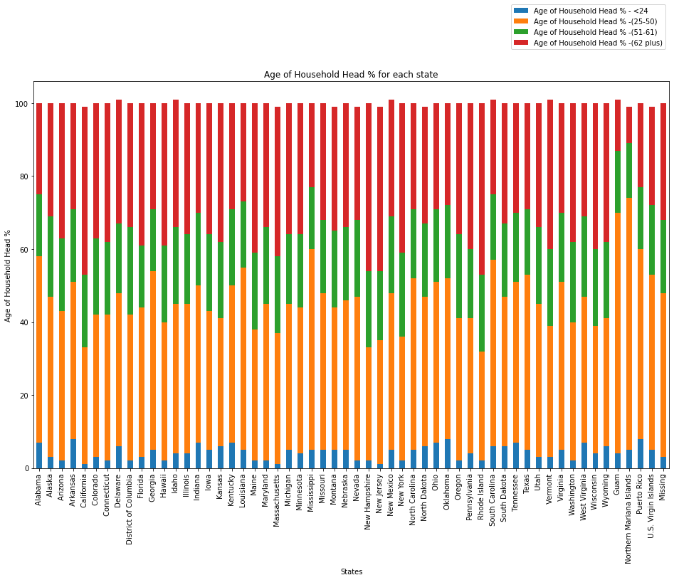

```python
##Creating a new dataframe for plotting
household_age = state_2018[["Age of Household Head % - <24",
                            "Age of Household Head % -(25-50)",
                            "Age of Household Head % -(51-61)",
                            "Age of Household Head % -(62 plus)"]]

##Setting indices and renaming cols
household_age.index = state_2018.index
household_age.columns = ['Age of Household Head % - <24',
                         'Age of Household Head % -(25-50)',
                         'Age of Household Head % -(51-61)',
                         'Age of Household Head % -(62 plus)']

##Plotting
household_age.plot.bar(stacked=True, xlabel="States", ylabel="Age of Household Head %",
                       figsize=(16, 10), title= "Age of Household Head % for each state")

##Moving legend outside for easier reading
plt.legend(loc='center right', bbox_to_anchor=(1.0, 1.14))
```

The stacked bar chart for the distribution of the race of heads of household in each states shows the race composition of the heads of affordable household. In this stacked bar chart, apart from Florida and Ohio where race data was not reported, we could not really observe a clear trend for the overall distribution of the race of heads of household for the rest of the states. Nevertheless, we may find that Gaum and Northern Mariana Islands have significantly higher portion of Asian heads of household than other states, and Puerto Rico has significantly higher portion of Hispanic heads of household than other states. This makes sense because the data corresponds to the race composition of total populaiton in each of those states repsectively. This may also explain why White heads of household are the majority in Idaho, Maine, Montana, New Hampshire, Vermont, and West Virginia, since according to THe United States Census Bureau, at least 80% of the population in these states are white. However, that does not explain why Afircan American heads of household makes up over 80% of the heads of household in District of Columbia, while African American peopel only makes up less than 50% of the DC population.

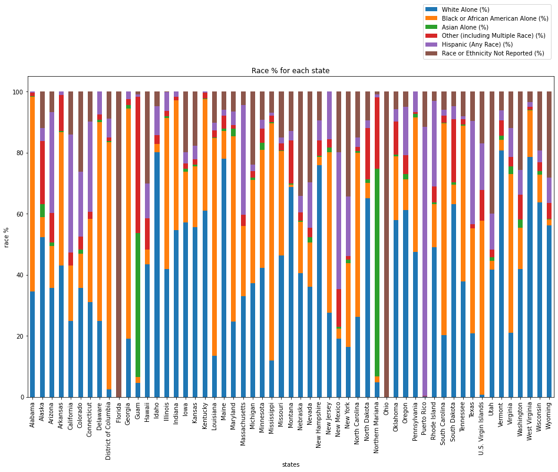

```python
##Creating a new dataframe for plotting
race_data_per_state = race_of_occp_df

##Put American Indian & Alaska Native Alone and Native Hawaiian and Other Pacific Islander Alone (%) together w/ Other catergory
race_data_per_state["Other (including Multiple Race) (%)"] = race_of_occp_df["American Indian and Alaska Native Alone (%)"] +race_of_occp_df["Native Hawaiian and Other Pacific Islander Alone (%)"] + race_of_occp_df["Other (including Multiple Race) (%)"]

##Dropping cols that aren't relevant
race_data_per_state = race_data_per_state.drop(columns = ["Properties Reported (%)", "American Indian and Alaska Native Alone (%)", "Native Hawaiian and Other Pacific Islander Alone (%)"])

##Plotting
race_data_per_state.plot.bar(stacked=True, xlabel="states", ylabel="race %", figsize=(16, 10), title= "Race % for each state")

##Moving legend outside of plot for easier viewing
plt.legend(loc='center right', bbox_to_anchor=(1.0, 1.14))
```

Now we are plotting a bar chart to show the median reported income of affordable households in each state, together with a stacked bar chart to show the distribution of the income of LIHTC households in each state, with an interval of 5,000 USD.

As the median income chart shows, the median income of households in Northern Mariana Islands is the highest, which is also reflected in the stacked bar chart as the households with income higher than 20,000 USD makes up more than 80% of the total households. Comparing both charts, we can see that for the states and territory with lower median income of households, such as Puerto Rico and Kentucky, the distribution of income is also negatively-skewed; that is, most of the households have relatively lower income. Besides, we can also see from the first chart that the majority of the states have a median income of households that is higher than 15,000 USD. The second chart confirms it as for most states, households with income above 15,000 USD makes up over 50% of the total households.

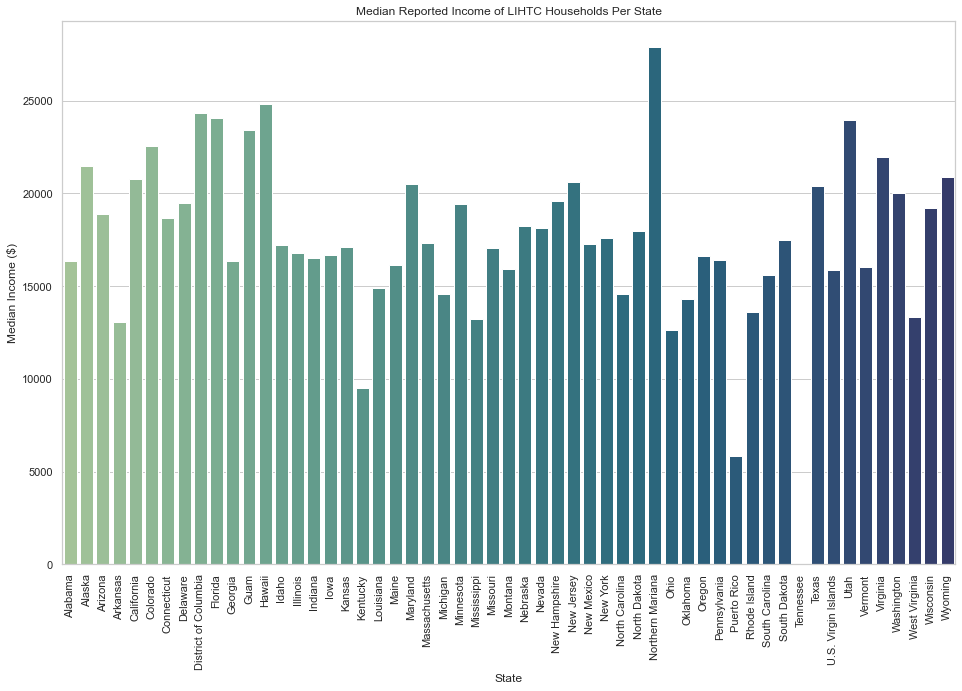

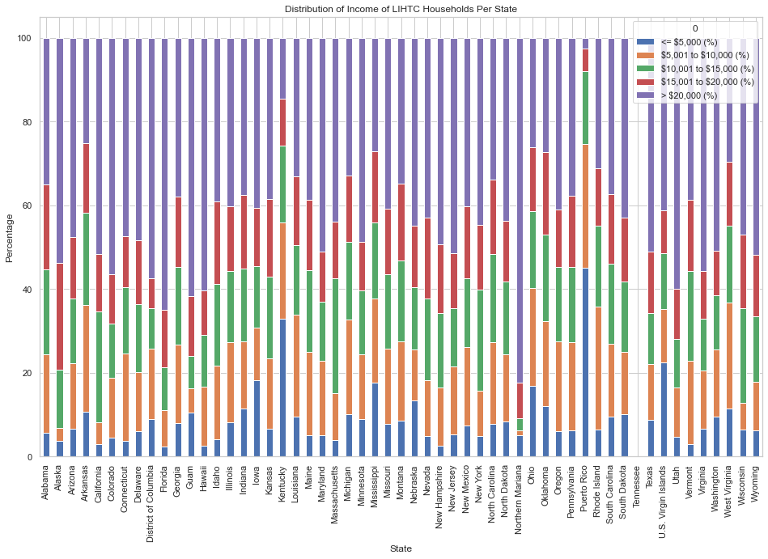

```python
# Set the figure size
plt.figure(figsize=(16,10))

# Set the figure style
sns.set_theme(style='whitegrid')

median_income_by_state = sns.barplot(y='Median Income ($)',
                                     x= household_income_df.index, data = household_income_df,
                                     palette=sns.color_palette("crest",
                                     household_income_df.index.size))
median_income_by_state.set_xticklabels(median_income_by_state.get_xticklabels(), rotation=90)

# Set the x- and y-axis labels and title
plt.xlabel('State')
plt.ylabel('Median Income ($)')
plt.title('Median Reported Income of LIHTC Households Per State')
plt.show()
distribution_of_income = pd.DataFrame(household_income_df[['<= $5,000 (%)',
                                                           '\$5,001 to \$10,000 (%)',
                                                           '\$10,001 to \$15,000 (%)',
                                                           '\$15,001 to \$20,000 (%)',
                                                           '> $20,000 (%)']])
distribution_of_income.plot.bar(figsize=(16,10), stacked=True, xlabel='State',
                                ylabel='Percentage',
                                title='Distribution of Income of LIHTC Households Per State')
```

Finally, we are plotting a bar chart to show the percentage of the reported amount of federal rental assistance and other federal rental assistance received in each state. The data is missing for some states, but with the reported data, we can observe that Ohio, Connecticut, North Carolina, Alabama, and Indiana have the highest amount of federal rental assistance.

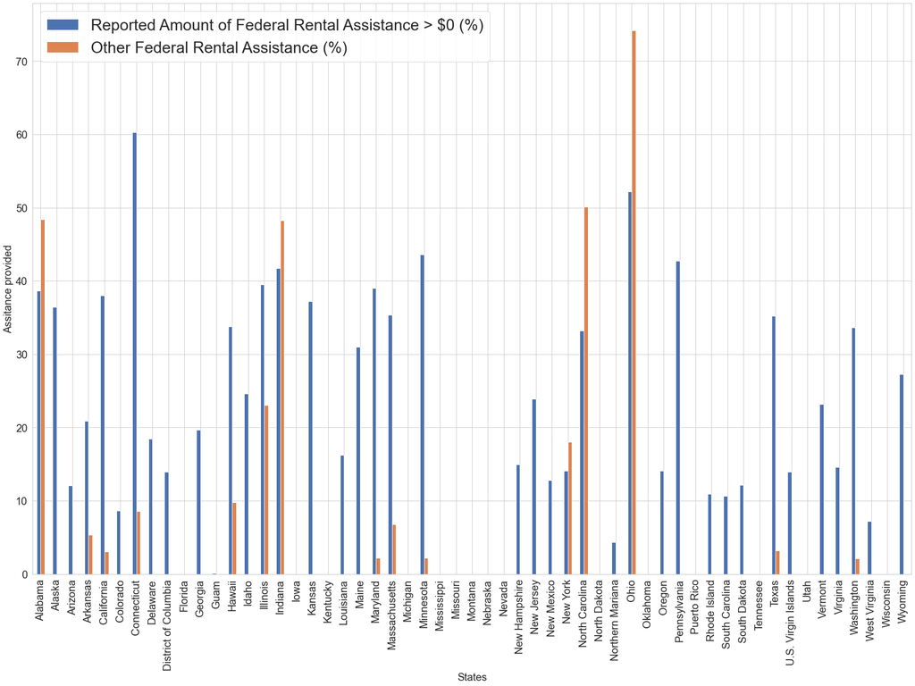

```python
cols = [federal_asst_df.columns[0], federal_asst_df.columns[9]]
ax = federal_asst_df.plot.bar(y=cols, figsize=(30,20))
plt.xlabel('States', fontsize=20)
plt.ylabel('Assitance provided', fontsize=20)
ax.tick_params(axis='both', which='major', labelsize=20)

ax.legend(prop={'size': 30})
plt.show()
```

## Phase 4: Hypothesis Testing:

From our exploratory analysis we have hypothesized some relations between the different characteristics of the occupants of the affordable housing units. Some of them are: 1) We believe that as the median income increases the occupancies of affordable housing should decrease. The idea is that with the increase in income, more occupants will be encouraged to move out of subsidised housing plans.  
2) We also hypothesize that we will see a decrease in median income with an increase in Black population. With the current political climate there are many inquiries into African American's being underpaid and we thought it would be relevent to test this hypothesis.  
3) Our third hypothesis is that with the increase in median income, we will see a sharp decline in requirement for federal or other rental assistance. This is a logic hypothesis, as we see an increase in income, we can expect families to pay for the subsidised housing themselves.

The aforementioned hypothesis are tested below using Linear regression models using the relevent columns and data that was collected and analysed above. For each hypothesis we have graphs and/or regression summaries that will be used to prove if our hypothesis is right, wrong or irrelevant (since there is no real relation).

```python
#Correlation occupancy of affordable housing and median income per state.
state_2018.index = state_2018.index.str.strip()
state_2018.sort_index(inplace=True)
state_2018 = state_2018.rename(index={'Northern Mariana Islands': 'Northern Mariana'})
state_2018 = state_2018.drop("Missing")
```

First, we will start by showing the scatter plot of median income versus affordable housing occupancy per unit for each state. In the scatter plot, we fit a regression line for median income versus affordable housing occupancy per unit. We would expect that if more people live in a unit, the higher the household income would be. As indicated by the regression line, the coefficient of the regression model is positive, which suggests that there is indeed a positive correlation between median income and affordable housing occupancy per unit. That is to say, with the increase of household income, we could expect to see more people living in the same household.  
We have a regression analysis summary for the graph below that can be used to understand how relevant are the conclusions made.

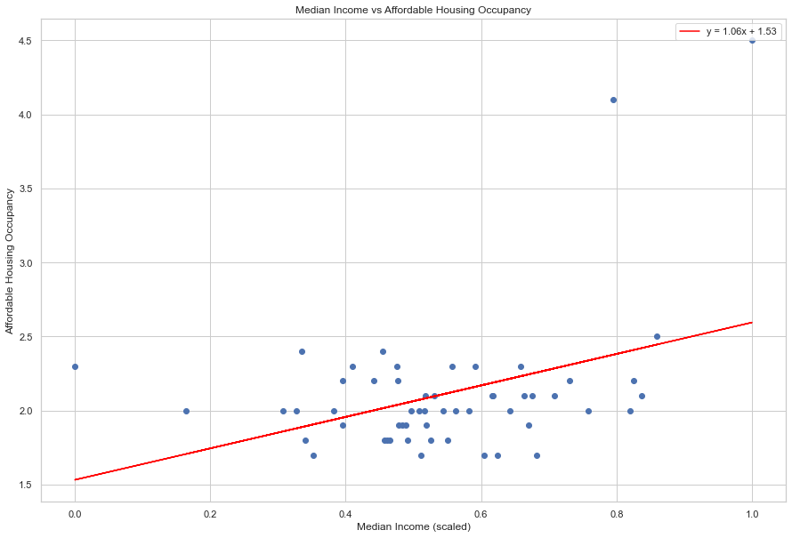

```python
##Missing val, replace val w/ mean of column (also is the default func of sklearn imputer)
household_income_df_mod = household_income_df.fillna(household_income_df.mean())

##OR replace w/ 0
#household_income_df["Median Income ($)"].fillna(0, inplace=True)

from sklearn.preprocessing import MinMaxScaler

# create a scaler object
scaler = MinMaxScaler()
# fit and transform the data
df_median_income = household_income_df_mod[["Median Income ($)"]]
df_norm_inc = pd.DataFrame(scaler.fit_transform(df_median_income),
                           columns=df_median_income.columns)

##Reshaping cols for linear regression
X = df_norm_inc["Median Income ($)"].values.reshape(-1,1)
Y = state_2018["Occupancy/unit"].values.reshape(-1,1)

##Creating linear regression
lin_regr = LinearRegression()
reg = lin_regr.fit(X, Y)

##Predictions
Y_pred = lin_regr.predict(X)

m = reg.coef_[0][0]
b = reg.intercept_[0]

line_label = "y = {:.2f}x + {:.2f}".format(m, b)

##Plotting
plt.figure(figsize=(15,10))
plt.scatter(X,Y)
plt.plot(X,Y_pred, color='red', label=line_label)
plt.xlabel("Median Income (scaled)")
plt.ylabel("Affordable Housing Occupancy")
plt.title("Median Income vs Affordable Housing Occupancy")
plt.legend(loc='upper right')

plt.show()
```

Looking at the summary of the regression results below, we can determine that the model is not a good fit for the data. The R^2 value is 0.154 which signified a weak correlation between median income and percentage of occupancy in affordable housing. However, since the p-value is less than 0.05, we can reject the null hypothesis that the slope of the regression is equal to zero. Overall, given the low correlation, median income is not a good predictor for percentage of occupancy in affordable housing.

```python
X2 = sm.add_constant(X)
model = sm.OLS(Y, X2)
results = model.fit()
print(results.summary())
```

```
                            OLS Regression Results
==============================================================================
Dep. Variable:                      y   R-squared:                       0.154
Model:                            OLS   Adj. R-squared:                  0.138
Method:                 Least Squares   F-statistic:                     9.617
Date:                Mon, 17 May 2021   Prob (F-statistic):            0.00309
Time:                        00:38:52   Log-Likelihood:                -32.011
No. Observations:                  55   AIC:                             68.02
Df Residuals:                      53   BIC:                             72.04
Df Model:                           1
Covariance Type:            nonrobust
==============================================================================
                 coef    std err          t      P>|t|      [0.025      0.975]
------------------------------------------------------------------------------
const          1.5314      0.196      7.832      0.000       1.139       1.924
x1             1.0631      0.343      3.101      0.003       0.376       1.751
==============================================================================
Omnibus:                       52.947   Durbin-Watson:                   1.892
Prob(Omnibus):                  0.000   Jarque-Bera (JB):              243.209
Skew:                           2.687   Prob(JB):                     1.54e-53
Kurtosis:                      11.789   Cond. No.                         7.51
==============================================================================

Notes:
[1] Standard Errors assume that the covariance matrix of the errors is correctly specified.
```

Next, we are showing median household income versus the percentage of Black or African American heads of household. Similar to the plot above, we are showing the scatter plot for each state, as well as a regression line to demonstrate the overall trend. From the plot we can see that most states that have a higher median income have a very low percentage of black population in their affordable housing. So as the Black population increases in affordable housing, we can see a slight decrease in the median income. The slope is not significant enough to make a strong correlation.

We will also be discussing the finding's of the regression summary to analyse if the conclusions from the plot and regression line are even relevant.

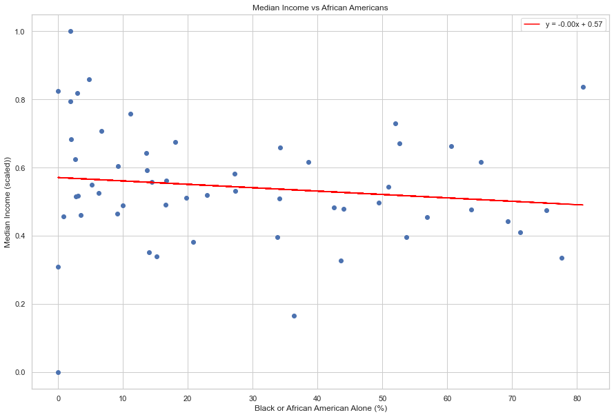

```python
##Median income vs African Americans

##Reshaping cols for linear regression
X = race_of_occp_df["Black or African American Alone (%)"].values.reshape(-1,1)
Y = df_norm_inc["Median Income ($)"].values.reshape(-1,1)

##Creating linear regression
lin_regr = LinearRegression()
reg = lin_regr.fit(X, Y)

##Predictions
Y_pred = lin_regr.predict(X)

m = reg.coef_[0][0]
b = reg.intercept_[0]

line_label = "y = {:.2f}x + {:.2f}".format(m, b)

##Plotting
plt.figure(figsize=(15,10))
plt.scatter(X,Y)
plt.plot(X,Y_pred, color='red', label=line_label)
plt.xlabel("Black or African American Alone (%)")
plt.ylabel("Median Income (scaled))")
plt.title("Median Income vs African Americans")
plt.legend(loc='upper right')

plt.show()
```

The model for the data is not a good fit. The P-Value is 0.310 which is much higher than 0.05, meaning we would not reject the null hypothesis that the slope is equal to zero. Also, the R^2 is 0.019 which is low indicating very little correlation between the percentage of African Americans and median income of a State.

```python
X2 = sm.add_constant(X)
model = sm.OLS(Y, X2)
results = model.fit()
print(results.summary())
```

```
                            OLS Regression Results
==============================================================================
Dep. Variable:                      y   R-squared:                       0.019
Model:                            OLS   Adj. R-squared:                  0.001
Method:                 Least Squares   F-statistic:                     1.051
Date:                Mon, 17 May 2021   Prob (F-statistic):              0.310
Time:                        00:38:52   Log-Likelihood:                 18.832
No. Observations:                  55   AIC:                            -33.66
Df Residuals:                      53   BIC:                            -29.65
Df Model:                           1
Covariance Type:            nonrobust
==============================================================================
                 coef    std err          t      P>|t|      [0.025      0.975]
------------------------------------------------------------------------------
const          0.5707      0.036     16.016      0.000       0.499       0.642
x1            -0.0010      0.001     -1.025      0.310      -0.003       0.001
==============================================================================
Omnibus:                        4.860   Durbin-Watson:                   1.703
Prob(Omnibus):                  0.088   Jarque-Bera (JB):                5.144
Skew:                          -0.264   Prob(JB):                       0.0764
Kurtosis:                       4.402   Cond. No.                         55.4
==============================================================================

Notes:
[1] Standard Errors assume that the covariance matrix of the errors is correctly specified.
```

Below is the scatter plot and the regression line graph for comparision between Federal assistance acquired and median income. In the epilogue for this phase we talk about seeing a sharp decline in requirement in assistance as median income increases. From the graph we can see an abundance of NaN (not reported) values in states. So below is the regression that includes all the NaN values, reporting them as 0. The trend line is surprisingly slightly positive, rejecting our hypothesis, that there would be a decline with an increase in median income. But this may not be relevant because the NaN values could be skewing the result drastically. Also the slope of the regression is not significant and from the graph we can see that this may not be a useful model.

We are also removing those NaN values in further analysis to find out if it would change the results towards our initial hypothesis.

```python
##Replace NaN w/ 0
federal_asst_df_mod = federal_asst_df.fillna(0)
```

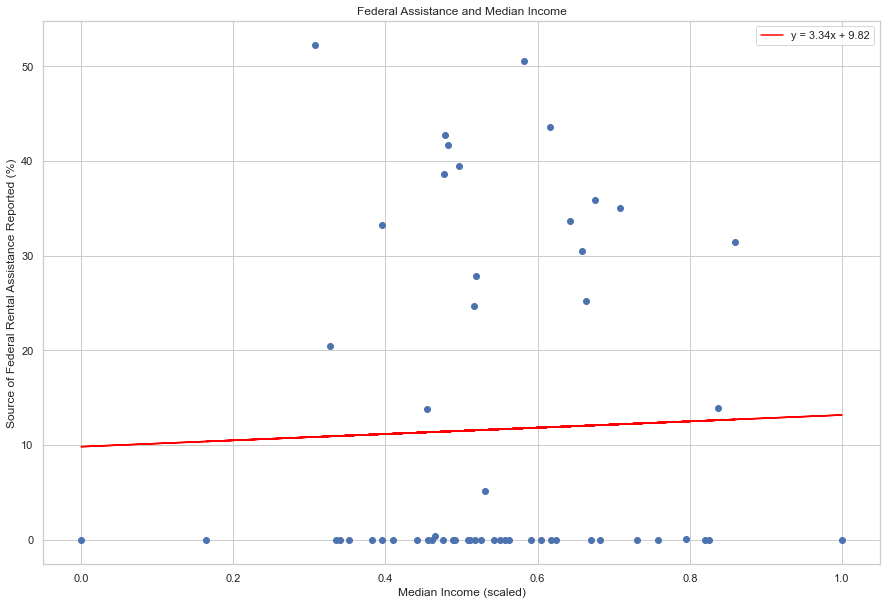

```python
## Correlation of federal assistance and median income

X = df_norm_inc["Median Income ($)"].values.reshape(-1,1)
Y = federal_asst_df["Source of Federal Rental Assistance Reported (%)"].values.reshape(-1,1)

##Creating linear regression
lin_regr = LinearRegression()
reg = lin_regr.fit(X, Y)

##Predictions
Y_pred = lin_regr.predict(X)

m = reg.coef_[0][0]
b = reg.intercept_[0]

line_label = "y = {:.2f}x + {:.2f}".format(m, b)

##Plotting
plt.figure(figsize=(15,10))
plt.scatter(X,Y)
plt.plot(X,Y_pred, color='red', label=line_label)
plt.xlabel("Median Income (scaled)")
plt.ylabel("Source of Federal Rental Assistance Reported (%)")
plt.title("Federal Assistance and Median Income")
plt.legend(loc='upper right')

plt.show()
```

As discussed in the parahraph above, we have removed the null values for the following regression model for the same values as before. We can now see that with all relevant values we have found that federal assistance required had a sharp decline as median income increases in the subsidised housing units. We believe this is consistant with our hypothesis at the epilogue of this phase. With all the graphs with Median income, we normalised the value to allow for a cleaner looking model. There is also a regression analysis summary below the graph that shows how relevant any visual finding's are in this model. Despite the sharp decline, their may be a high change of the model having weak correlation or null slope. That can be determined by analysing the regression summary.

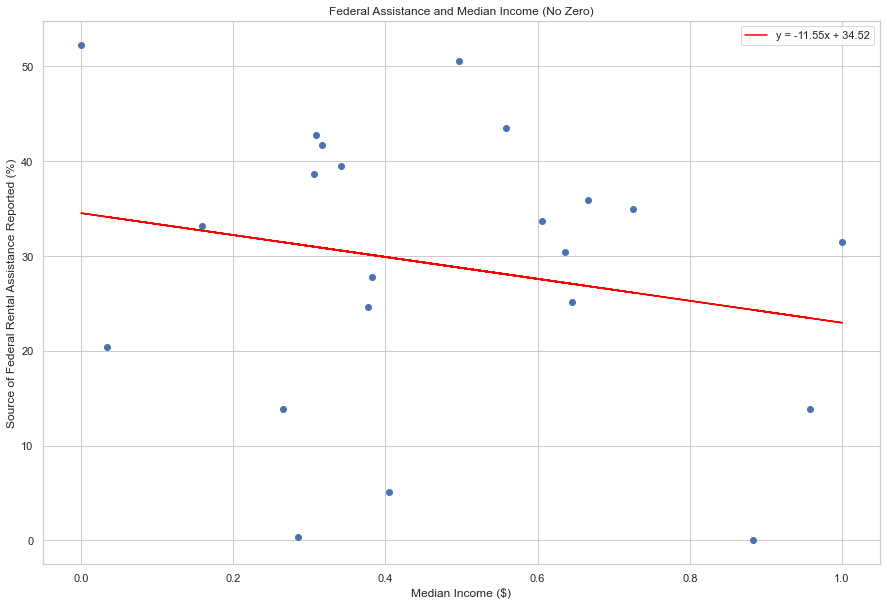

```python
## Correlation of federal assistance and median income (without zeros)

federal_asst_df_nozero = federal_asst_df_mod.loc[federal_asst_df_mod[
    "Source of Federal Rental Assistance Reported (%)"] != 0, :]
household_income_df_nozero = household_income_df_mod.loc[federal_asst_df_nozero.index, :]

df_median_income = household_income_df_nozero[["Median Income ($)"]]
df_norm_inc_nozero = pd.DataFrame(scaler.fit_transform(df_median_income),
                                  columns=df_median_income.columns)

results = model.fit()
X = df_norm_inc_nozero["Median Income ($)"].values.reshape(-1,1)
Y = federal_asst_df_nozero["Source of Federal Rental Assistance Reported (%)"].values.reshape(-1,1)

##Creating linear regression
lin_regr = LinearRegression()
reg = lin_regr.fit(X, Y)

##Predictions
Y_pred = lin_regr.predict(X)

m = reg.coef_[0][0]
b = reg.intercept_[0]

line_label = "y = {:.2f}x + {:.2f}".format(m, b)

##Plotting
plt.figure(figsize=(15,10))
plt.scatter(X,Y)
plt.plot(X,Y_pred, color='red', label=line_label)
plt.xlabel("Median Income ($)")
plt.ylabel("Source of Federal Rental Assistance Reported (%)")
plt.title("Federal Assistance and Median Income (No Zero)")
plt.legend(loc='upper right')

plt.show()
```

Looking at the summary of the regression results we can determine that the model is not a good fit for the data. The R^2 value is 0.045 which signified a weak correlation between the source of federal rental assistance reported and median income. Since the p-value is 0.344, more than 0.05, we do not reject the null hypothesis that the slope of the regression is equal to zero. Overall, given the low correlation, median income is not a good predictor for source of federal rental assistance.

```python
X2 = sm.add_constant(X)
model = sm.OLS(Y, X2)
results = model.fit()
print(results.summary())
```

```
                            OLS Regression Results
==============================================================================
Dep. Variable:                      y   R-squared:                       0.045
Model:                            OLS   Adj. R-squared:                 -0.003
Method:                 Least Squares   F-statistic:                    0.9388
Date:                Mon, 17 May 2021   Prob (F-statistic):              0.344
Time:                        00:38:53   Log-Likelihood:                -89.689
No. Observations:                  22   AIC:                             183.4
Df Residuals:                      20   BIC:                             185.6
Df Model:                           1
Covariance Type:            nonrobust
==============================================================================
                 coef    std err          t      P>|t|      [0.025      0.975]
------------------------------------------------------------------------------
const         34.5171      6.454      5.349      0.000      21.055      47.979
x1           -11.5523     11.923     -0.969      0.344     -36.423      13.318
==============================================================================
Omnibus:                        2.222   Durbin-Watson:                   2.324
Prob(Omnibus):                  0.329   Jarque-Bera (JB):                1.886
Skew:                          -0.656   Prob(JB):                        0.389
Kurtosis:                       2.419   Cond. No.                         4.62
==============================================================================

Notes:
[1] Standard Errors assume that the covariance matrix of the errors is correctly specified.
```

Since we had two different values of rental assitance, we have also done regression analysis for the other rental assistance acquired at these subsidised hosuing units. The graph below also includes all the NaN (not reported) values in our analysis. Despite that skewing our results we see a clear negative slope, determining that need for rental assistance decreases as income increases. Although, much like the Federal Assistance regression model above, we can conclude from the regression summary that the model is not a good fit due to low correaltion and a very high p-value.

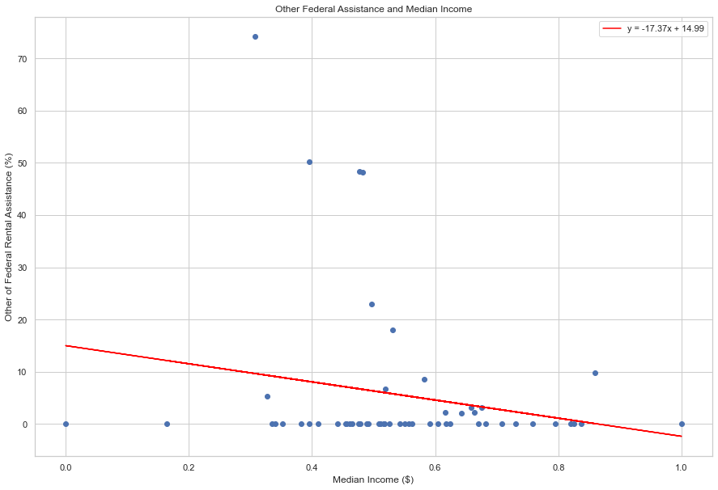

```python
##Correlation of other federal assistance and median income
X = df_norm_inc["Median Income ($)"].values.reshape(-1,1)
Y = federal_asst_df_mod["Other Federal Rental Assistance (%)"].values.reshape(-1,1)

##Creating linear regression
lin_regr = LinearRegression()
reg = lin_regr.fit(X, Y)

##Predictions
Y_pred = lin_regr.predict(X)

m = reg.coef_[0][0]
b = reg.intercept_[0]

line_label = "y = {:.2f}x + {:.2f}".format(m, b)

##Plotting
plt.figure(figsize=(15,10))
plt.scatter(X,Y)
plt.plot(X,Y_pred, color='red', label=line_label)
plt.xlabel("Median Income ($)")
plt.ylabel("Other of Federal Rental Assistance (%)")
plt.title("Other Federal Assistance and Median Income")
plt.legend(loc='upper right')

plt.show()
```

```python
X2 = sm.add_constant(X)
model = sm.OLS(Y, X2)
results = model.fit()
print(results.summary())
```

```
                            OLS Regression Results
==============================================================================
Dep. Variable:                      y   R-squared:                       0.041
Model:                            OLS   Adj. R-squared:                  0.023
Method:                 Least Squares   F-statistic:                     2.278
Date:                Mon, 17 May 2021   Prob (F-statistic):              0.137
Time:                        00:38:53   Log-Likelihood:                -225.26
No. Observations:                  55   AIC:                             454.5
Df Residuals:                      53   BIC:                             458.5
Df Model:                           1
Covariance Type:            nonrobust
==============================================================================
                 coef    std err          t      P>|t|      [0.025      0.975]
------------------------------------------------------------------------------
const         14.9893      6.565      2.283      0.026       1.822      28.156
x1           -17.3709     11.509     -1.509      0.137     -40.455       5.713
==============================================================================
Omnibus:                       53.625   Durbin-Watson:                   1.664
Prob(Omnibus):                  0.000   Jarque-Bera (JB):              216.625
Skew:                           2.846   Prob(JB):                     9.13e-48
Kurtosis:                      10.882   Cond. No.                         7.51
==============================================================================

Notes:
[1] Standard Errors assume that the covariance matrix of the errors is correctly specified.
```

This model below is performing regression on the values above, but after filtering out all the NaN values. This model fits our initial hypothesis, since we can see a very sharp decline in the need for other (non-federal) rental assistance as median income rises. Certain values on the scatter plot also fit our model as they report requiring very high rental assistance at the lowest end of median income.  
Our regression analysis summary below will help us determine if this a good fit model.

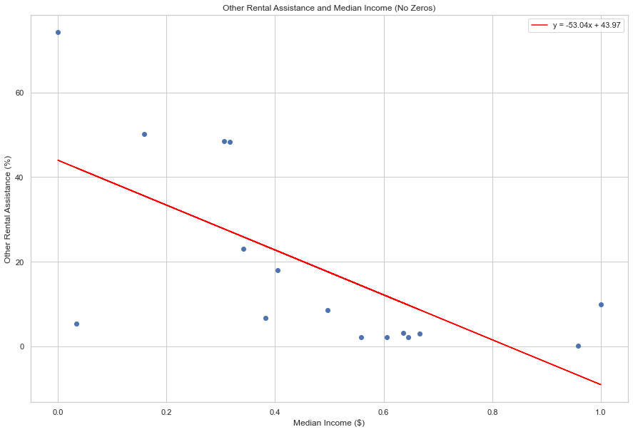

```python
federal_asst_df_nozero = federal_asst_df_mod.loc[federal_asst_df_mod[
    "Other Federal Rental Assistance (%)"] != 0, :]
household_income_df_nozero = household_income_df_mod.loc[federal_asst_df_nozero.index, :]

df_median_income = household_income_df_nozero[["Median Income ($)"]]
df_norm_inc_nozero = pd.DataFrame(scaler.fit_transform(df_median_income),
                                  columns=df_median_income.columns)

X = df_norm_inc_nozero["Median Income ($)"].values.reshape(-1,1)
Y = federal_asst_df_nozero["Other Federal Rental Assistance (%)"].values.reshape(-1,1)

##Creating linear regression
lin_regr = LinearRegression()
reg = lin_regr.fit(X, Y)

##Predictions
Y_pred = lin_regr.predict(X)

m = reg.coef_[0][0]
b = reg.intercept_[0]

line_label = "y = {:.2f}x + {:.2f}".format(m, b)

##Plotting
plt.figure(figsize=(15,10))
plt.scatter(X,Y)
plt.plot(X,Y_pred, color='red', label=line_label)
plt.xlabel("Median Income ($)")
plt.ylabel("Other Rental Assistance (%)")
plt.title("Other Rental Assistance and Median Income (No Zeros)")
plt.legend(loc='upper right')

plt.show()
```

This model is one of the best fits we have in our analysis. The R^2 value is 0.432 which signified a moderate correlation between the other federal rental assistance reported with omitting zeros and median income. Since the p-value is 0.00563, less than 0.05, we do reject the null hypothesis that the slope of the regression is equal to zero. Overall, given the moderate correlation, it seems median income could be used as predictor for other rental assistance reported after omitting zeros and non-reported values.

```python
X2 = sm.add_constant(X)
model = sm.OLS(Y, X2)
results = model.fit()
print(results.summary())
```

```
                            OLS Regression Results
==============================================================================
Dep. Variable:                      y   R-squared:                       0.432
Model:                            OLS   Adj. R-squared:                  0.392
Method:                 Least Squares   F-statistic:                     10.67
Date:                Mon, 17 May 2021   Prob (F-statistic):            0.00563
Time:                        00:38:53   Log-Likelihood:                -67.882
No. Observations:                  16   AIC:                             139.8
Df Residuals:                      14   BIC:                             141.3
Df Model:                           1
Covariance Type:            nonrobust
==============================================================================
                 coef    std err          t      P>|t|      [0.025      0.975]
------------------------------------------------------------------------------
const         43.9671      8.850      4.968      0.000      24.987      62.948
x1           -53.0370     16.239     -3.266      0.006     -87.867     -18.207
==============================================================================
Omnibus:                        0.037   Durbin-Watson:                   1.925
Prob(Omnibus):                  0.982   Jarque-Bera (JB):                0.109
Skew:                          -0.044   Prob(JB):                        0.947
Kurtosis:                       2.605   Cond. No.                         4.46
==============================================================================

Notes:
[1] Standard Errors assume that the covariance matrix of the errors is correctly specified.
```

Here we are doing a regression analysis between Median income and age groups. We wanted to do this analysis to see if median income of a household decreases with an increase in certain age group's as head of household. We hypothesized that with higher median income we may see a decrease in older household heads (over 65), but we were proven wrong.  
The only graph with a significant slope is the first one reporting regression between median income and occupants below 24. As we can see as the percentage of 24 year below household head's increased, we can see a decline in median income. This may mean that younger's household heads may have unstable lower paying jobs, thus bringing down the median income in states where they are majority of the household heads in subsidised housing.

[figure not shown]

[figure not shown]

[figure not shown]

[figure not shown]

[figure not shown]

```python
#Each age group is correlated with median income
age_groups = ["Age of Household Head % - <24",
              "Age of Household Head % -(25-50)",
              "Age of Household Head % -(51-61)",
              "Age of Household Head % -(62 plus)",
              "Age of Household Head % -(85 plus)"]

Y = household_income_df_mod["Median Income ($)"].values.reshape(-1,1)

for age in age_groups:
    ##Getting age group vals
    X = state_2018[age].values.reshape(-1,1)

    ##Creating linear regression
    lin_regr = LinearRegression()
    lin_regr.fit(X, Y)

    ##Predictions
    Y_pred = lin_regr.predict(X)

    m = reg.coef_[0][0]
    b = reg.intercept_[0]

    line_label = "y = {:.2f}x + {:.2f}".format(m, b)

    ##Plotting
    plt.figure(figsize=(15,10))
    plt.scatter(X,Y)
    plt.plot(X,Y_pred, color='red', label=line_label)
    plt.xlabel(age)
    plt.ylabel("Median Income ($)")
    plt.title(age + " vs Median Income ($)")
    plt.legend(loc='upper right')
    plt.show()
```

## Phase 5: Conclusion:

### Recap and insights:

With this project we set out to find relationships between different aspects of occupants of subsidised (or affordable) housing initiatives (like race, income range, disabilities and age). We not only wanted to understand the type of people living in these facilties, but also their reasons and numbers. We initially hypothesized that people of African American descent will be a majority in these housing initiatives. From the analysis we realised that it was true, but was also highly dependent on the general population and many other factors in that particular state.

This fulfills the objective of the project and we have received some interesting and some unexpected insights from our analysis. I believe with more extensively reported data, we may have been able to find better models corelating our points of interests and may have gained more insights into the subsidised housing initiatives and the people who live there.

As a tutorial this project tries to comment, label and explain every aspect of data colelction, cleanup, analysis and testing. We try to simplify each unique line of code and help the reader understand, thus trying to making the best possible tutorial explaining the data science pipeline through the project.